# main_analyses_mcs

Georgia Turner

2023-04-27

In this script we answer RQ2 onwards.

First, set up document:

```r
knitr::opts_chunk$set(echo = TRUE)
rm(list = ls())    # clear environment
set.seed(20230427) # set seed for any random samplings
```

```r
library(tidyverse)
library(VIM) # for KNN imputation
library(cluster) # for similarity matrix for multidimensional scaling analysis
library(vegan) # for MDS
library(mclust) # for gaussian mixture modelling
library(fclust) # for fuzzy clustering
library(glmnet)
library(fastDummies)
library(officer)
library(flextable)
library(gridExtra)
library(grid)
library(ellipse)
library(rstatix)
library(purrr)
library(emmeans)
source('00-functions.R')
```

First we define some plotting parameters, including variable renaming and colour scheme to add to plots throughout.

```r
var_renames <- c(
  # --- Mental health & wellbeing ---
  "kessl_depression"          = "Kessler Depression",
  "warwick_wellbeing"         = "Warwick Wellbeing",
  "self_esteem_1"             = "Self esteem: Satisfied",
  "self_esteem_2"             = "Self esteem: Good qualities",
  "self_esteem_3"             = "Self esteem: Competent",
  "self_esteem_4"             = "Self esteem: Valuable person",
  "self_esteem_5"             = "Self esteem: Feel good about self",

  # --- SDQ self-report ---
  "cm_sdq_emotion"            = "Self SDQ: Emotional symptoms",
  "cm_sdq_conduct"            = "Self SDQ: Conduct problems",
  "cm_sdq_hyper"              = "Self SDQ: Hyperactivity",
  "cm_sdq_peer"               = "Self SDQ: Peer problems",
  "cm_sdq_prosoc"             = "Self SDQ: Prosocial behaviour",

  # --- SDQ parent-report ---
  "pa_sdq_emotion"            = "Parent SDQ: Emotional symptoms",
  "pa_sdq_conduct"            = "Parent SDQ: Conduct problems",
  "pa_sdq_hyper"              = "Parent SDQ: Hyperactivity",
  "pa_sdq_peer"               = "Parent SDQ: Peer problems",
  "pa_sdq_prosoc"             = "Parent SDQ: Prosocial behaviour",

  # --- Personality & self-control ---
  "personality_open"          = "Openness",
  "personality_conscientious" = "Conscientiousness",
  "personality_extravert"     = "Extraversion",
  "personality_agreeable"     = "Agreeableness",
  "personality_neurot"        = "Neuroticism",
  "self_control"              = "Self control",

  # --- Social support & family ---
  "social_provision_safe_happy" = "Feels safe and happy",
  "social_provision_trust"      = "Trust in others",
  "social_provision_noone_close"= "No one close to talk to",
  "n_siblings"                  = "Number of siblings",
  "par_reported_closeness"      = "Parental closeness",
  "par_reported_talking"        = "Parental communication",
  "par_reported_monitoring"     = "Parental monitoring",
  "par_reported_curfew"         = "Parental curfew rules",

  # --- Lifestyle & health behaviours ---
  "smoking"                    = "Smokes cigarettes",
  "vaping"                     = "Vapes",
  "exercise"                   = "Exercise frequency",
  "sleep_quality"              = "Sleep quality",

  # --- Activities & hobbies ---
  "activity_party"             = "Frequency of partying",
  "activity_theatre"           = "Frequency of Theatre",
  "activity_watchsport"        = "Frequency of watching sport",
  "activity_music"             = "Frequency of playing music",
  "activity_gig"               = "Frequency attending gigs",
  "activity_read"              = "Frequency of reading",
  "activity_organised"         = "Frequency of organised group activity",
  "activity_library"           = "Frequency of library visits",
  "activity_museum"            = "Frequency of museum visits",
  "activity_volunteering"      = "Frequency of volunteering",
  "activity_political"         = "Frequency of political engagement",
  "activity_religious"         = "Frequency of religious activity",
  "activity_friends"           = "Frequency of seeing friends",

  # --- Media & tech ---
  "television_hrs"             = "Television hours",
  "gaming_hrs"                 = "Gaming hours",

  # --- Clinical & self-harm ---
  "clin_dep_anx_Yes"           = "Clinical depression/anxiety",
  "self_harm_1_I_do_not_wish_to_answer" = "Self-harm Q1: Prefer not to say",
  "self_harm_1_Yes"            = "Self-harm Q1: Yes",
  "self_harm_2_I_do_not_wish_to_answer" = "Self-harm Q2: Prefer not to say",
  "self_harm_2_Yes"            = "Self-harm Q2: Yes",
  "self_harm_3_I_do_not_wish_to_answer" = "Self-harm Q3: Prefer not to say",
  "self_harm_3_Yes"            = "Self-harm Q3: Yes",
  "self_harm_4_I_do_not_wish_to_answer" = "Self-harm Q4: Prefer not to say",
  "self_harm_4_Yes"            = "Self-harm Q4: Yes",
  "self_harm_5_I_do_not_wish_to_answer" = "Self-harm Q5: Prefer not to say",
  "self_harm_5_Yes"            = "Self-harm Q5: Yes",
  "self_harm_6_I_do_not_wish_to_answer" = "Self-harm Q6: Prefer not to say",
  "self_harm_6_Yes"            = "Self-harm Q6: Yes",
  "suic_attempt_Yes"           = "Suicide attempt: Yes",

  # --- Risk preferences ---
  "risk_pref_01_A_50-50_chance_of_£240" = "Risk pref 1: Uncertain option",
  "risk_pref_02_A_50-50_chance_of_£240" = "Risk pref 2: Uncertain option",
  "risk_pref_03_A_50-50_chance_of_£240" = "Risk pref 3: Uncertain option",
  "risk_pref_04_A_50-50_chance_of_£240" = "Risk pref 4: Uncertain option",
  "risk_pref_05_A_50-50_chance_of_£240" = "Risk pref 5: Uncertain option",
  "risk_pref_06_A_50-50_chance_of_£240" = "Risk pref 6: Uncertain option",
  "risk_pref_07_A_50-50_chance_of_£240" = "Risk pref 7: Uncertain option",
  "risk_pref_08_£48_for_certain"        = "Risk pref 8: Certain option",
  "risk_pref_09_£36_for_certain"        = "Risk pref 9: Certain option",
  "risk_pref_10_£24_for_certain"        = "Risk pref 10: Certain option",

  # --- Time preferences ---
  "time_pref_01_£50_in_four_months"     = "Time pref 1: Delayed reward",
  "time_pref_02_£52_in_four_months"     = "Time pref 2: Delayed reward",
  "time_pref_03_£55_in_four_months"     = "Time pref 3: Delayed reward",
  "time_pref_04_£60_in_four_months"     = "Time pref 4: Delayed reward",
  "time_pref_05_£70_in_four_months"     = "Time pref 5: Delayed reward",
  "time_pref_06_£80_in_four_months"     = "Time pref 6: Delayed reward",
  "time_pref_07_£90_in_four_months"     = "Time pref 7: Delayed reward",
  "time_pref_08_£50_in_two_months"      = "Time pref 8: Immediate reward",
  "time_pref_09_£50_in_two_months"      = "Time pref 9: Immediate reward",
  "time_pref_10_£50_in_two_months"      = "Time pref 10: Immediate reward",

  # --- Sexual orientation ---
  "sexuality_Mainly_heterosexual/_straight" = "Mainly heterosexual",
  "sexuality_Bisexual"                     = "Bisexual",
  "sexuality_Completely_gay_or_lesbian"    = "Completely gay/lesbian",
  "sexuality_Other"                        = "Sexuality: Other",
  "sexuality_Mainly_gay_or_lesbian"        = "Mainly gay/lesbian",
  "sexuality_Prefer_not_to_say"            = "Sexuality: Prefer not to say",
  "sexuality_Do_not_know"                  = "Sexuality: Don't know",

  # --- Victimisation ---
  "victimisation_insults_Yes"     = "Victim: Insults",
  "victimisation_gossip_Yes"      = "Victim: Gossip",
  "victimisation_violence_Yes"    = "Victim: Violence",
  "victimisation_weapon_Yes"      = "Victim: Threatened with weapon",
  "victimisation_theft_Yes"       = "Victim: Theft",
  "victimisation_harass_Yes"      = "Victim: Harassment",
  "victimisation_pics_Yes"        = "Victim: Pictures shared",
  "victimisation_sexapproach_Yes" = "Victim: Sexual approach",

  # --- Family & living situation ---
  "n_parents_One_parent/carer"    = "One parent/carer",
  "livewith_parents_Yes"          = "Lives with parents",
  "caring_responsibility_Yes"     = "Caring responsibilities",

  # --- Current activity/status ---
  "doing_with_time_SCHOOL_AND_WORK"             = "School and work",
  "doing_with_time_SCHOOL_AND_TRAINING"         = "School and training",
  "doing_with_time_JOB"                         = "Employed (job)",
  "doing_with_time_APPRENTICESHIP"              = "Apprenticeship",
  "doing_with_time_UNEMPLOYED_AND_SEARCHING_FOR_PAID_WORK" = "Unemployed, seeking work",
  "doing_with_time_NO_CURRENT_ACTIVITY"         = "No current activity",
  "doing_with_time_TRAINING"                    = "Training only",
  "doing_with_time_LOOKING_AFTER_HOME_OR_FAMILY_FULL_TIME" = "Caring full-time",

  # --- Risky & antisocial behaviour ---
  "sex_intercourse_Yes"          = "Had sexual intercourse",
  "alcohol_Yes"                  = "Consumes alcohol",
  "drug_cannabis_Yes"            = "Used cannabis",
  "drug_cocaine_Yes"             = "Used cocaine",
  "drug_lsd_Yes"                 = "Used LSD",
  "drug_ecstasy_Yes"             = "Used ecstasy",
  "drug_speed_Yes"               = "Used amphetamines",
  "drug_semeron_Yes"             = "Used semeron",
  "drug_ket_Yes"                 = "Used ketamine",
  "drug_meph_Yes"                = "Used mephedrone",
  "drug_psychoact_Yes"           = "Used psychoactive substances",

  # --- Risky behaviours ---
  "risky_shoplift_Yes"           = "Risky: Shoplifting",
  "risky_graffiti_Yes"           = "Risky: Graffiti",
  "risky_vandal_Yes"             = "Risky: Vandalism",
  "risky_robhome_Yes"            = "Risky: Home robbery",
  "risky_robvehicle_Yes"         = "Risky: Vehicle theft",
  "risky_fire_Yes"               = "Risky: Fire setting",
  "risky_creditcard_Yes"         = "Risky: Credit card fraud",
  "risky_hack_Yes"               = "Risky: Hacking",
  "risky_webvirus_Yes"           = "Risky: Sent web virus",

  # --- Antisocial behaviour ---
  "antisocial_hit_Yes"           = "Antisocial: Physical fight",
  "antisocial_weapon_Yes"        = "Antisocial: Weapon use",
  "antisocial_theft_Yes"         = "Antisocial: Theft",
  "antisocial_webharass_Yes"     = "Antisocial: Online harassment",
  "antisocial_webpics_Yes"       = "Antisocial: Sharing images",
  "antisocial_sexual_Yes"        = "Antisocial: Sexual offence",

  # --- Gambling, gangs, and crime ---
  "gambling_1_Yes"               = "Gambling: Fruit machines",
  "gambling_2_Yes"               = "Gambling: Private/friendly bet",
  "gambling_3_Yes"               = "Gambling: Betting shop",
  "gambling_4_Yes"               = "Gambling: Other or online",
  "weapon_carry_Yes"             = "Carried weapon",
  "gang_member_I_used_to_be_a_member_but_not_any_more" = "Former gang member",
  "gang_member_Yes"              = "Current gang member",
  "police_warning_Yes"           = "Received police warning",
  "police_arrest_Yes"            = "Arrested by police"
)

highSMA_cluster_colours <- c(
  "1" = "#B34CC2",  # rich purple
  "2"  = "#6BCB3D",  # lighter, fresher green
  "3" = "#F4A300"   # slightly more yellowy orange
)
all_cluster_colours <- c(
  "1" = "#FFB6C1",
  "2" = "#654321"

)
```

Load in processed data & create datasets.

```r
datproc_path <- "./../data_processed/"

dat_NotImputed    <- read_csv(str_c(datproc_path, "2025-07-28_11-00mcs_processed.csv"))
## datasets with all in
dat_imputed_all_train <- read_csv(str_c(datproc_path, "2025-08-21_13-08train-all-imputed.csv"))
dat_imputed_all_test  <- read_csv(str_c(datproc_path,  "2025-08-21_13-12test-all-imputed.csv"))
## datasets with just high SMA
mcsid_cm_SMA    <- dat_NotImputed %>%
  filter(!is.na(sma)) %>%
  dplyr::select(mcsid_cm, sma)

### train
# first filter to answered the SMA question
dat_imputed_SMA_train         <- filter(dat_imputed_all_train, mcsid_cm %in% mcsid_cm_SMA$mcsid_cm) %>%
  left_join(mcsid_cm_SMA, by = "mcsid_cm")
# Then separate by the answer
dat_imputed_highSMA_train     <- filter(dat_imputed_SMA_train, sma == "Agree" | sma == "Strongly agree") %>%
  dplyr::select(-sma)
dat_imputed_lowSMA_train      <- filter(dat_imputed_SMA_train, sma == "Disagree" | sma == "Strongly disagree") %>%
  dplyr::select(-sma)

### test
# first filter to answered the SMA question
dat_imputed_SMA_test          <- filter(dat_imputed_all_test, mcsid_cm %in% mcsid_cm_SMA$mcsid_cm) %>%
  left_join(mcsid_cm_SMA, by = "mcsid_cm")
# Then separate by the answer
dat_imputed_highSMA_test      <- filter(dat_imputed_SMA_test, sma == "Agree" | sma == "Strongly agree") %>%
  dplyr::select(-sma)
dat_imputed_lowSMA_test       <- filter(dat_imputed_SMA_test, sma == "Disagree" | sma == "Strongly disagree") %>%
  dplyr::select(-sma)
```

In the previous scripts (‘explore_clustering_parameters_train…’) we examined different dimensionality reduction and clustering parameters, and established that clusters emerge in the training dataset, for both all and high SMA, at dimensionality reduction to 2 MDS dimensions, with 2 clusters providing separation using Gaussian mixture modelling for all participants, and 3 clusters for high SMA.

Therefore, in this script we perform clustering using these analysis variables (MDS dimensions = 2, clusters = 2 for all; 3 for high SMA).

First we do MDS. We perform MDS to extract dimensions from the training dataset, then project the testing dataset onto these dimensions.

```r
set.seed(2)

#### now perform for all

dat_imputed_all_train_mds       <- perform_mds_train(dat_imputed_all_train, remove_cols = "mcsid_cm")
dat_imputed_all_test_mds_points <- project_mds_test(
  train_data  = dat_imputed_all_train,
  test_data   = dat_imputed_all_test,
  mds_result  = dat_imputed_all_train_mds,
  remove_cols = "mcsid_cm"
)

dat_imputed_highSMA_train_mds       <- perform_mds_train(dat_imputed_highSMA_train, remove_cols = "mcsid_cm")
# flip dimensions as on inspection if they are flipped they are more similar to the dimensions in the 'All' dataset, and MDS is invariant to reflection so that should be fine.
dat_imputed_highSMA_train_mds       <- flip_mds_dimensions(dat_imputed_highSMA_train_mds)
dat_imputed_highSMA_test_mds_points <- project_mds_test(
  train_data  = dat_imputed_highSMA_train,
  test_data   = dat_imputed_highSMA_test,
  mds_result  = dat_imputed_highSMA_train_mds,
  remove_cols = "mcsid_cm"
)
```

Compare MDS dimensions for all:

[figure not shown]

```r
set.seed(55)

varCorrs_all <- plot_mds_variable_correlations(
  mds_train   = dat_imputed_all_train_mds$points,
  mds_test    = dat_imputed_all_test_mds_points,
  vars_train  = dplyr::select(dat_imputed_all_train, -mcsid_cm),
  vars_test   = dplyr::select(dat_imputed_all_test, -mcsid_cm),
  title_train = "All Train",
  title_test  = "All Test"
)
```

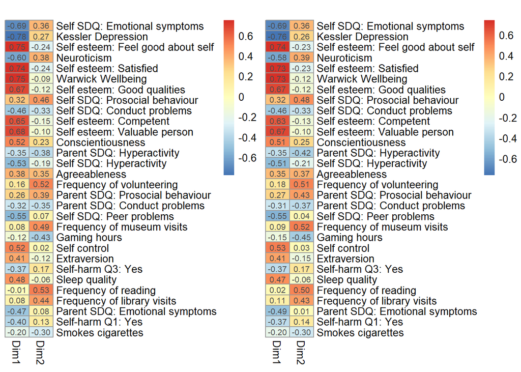

```r
# S02a shows only the first 30 most important dimensions for ease of visualisation; S03a shows all dimensions.

FigS02a_plot <-  plot_mds_variable_correlations(
  mds_train   = dat_imputed_all_train_mds$points,
  mds_test    = dat_imputed_all_test_mds_points,
  vars_train  = dplyr::select(dat_imputed_all_train, -mcsid_cm),
  vars_test   = dplyr::select(dat_imputed_all_test, -mcsid_cm),
  title_train = "",
  title_test  = "",
    top_n = 30,
  rename_vars = TRUE,
  var_name_map =
    var_renames
)$p_test
```

[figure not shown]

```r
ggsave("figures/FigS02a.pdf", plot = FigS02a_plot, bg = "white",  width = 7, height = 4.5, units = "in")

FigS03a_plot <-  plot_mds_variable_correlations(
  mds_train = dat_imputed_all_train_mds$points,
  mds_test  = dat_imputed_all_test_mds_points,
  vars_train = dplyr::select(dat_imputed_all_train, -mcsid_cm),
  vars_test  = dplyr::select(dat_imputed_all_test, -mcsid_cm),
  title_train = "",
  title_test  = "",
  rename_vars = TRUE,
  var_name_map =
    var_renames
)$p_test
```

```r
ggsave("figures/FigS03a.pdf", plot = FigS03a_plot, bg = "white",  width = 7, height = 20, units = "in")
```

Now for high SMA:

[figure not shown]

[output not shown]

[output cut: 804 more lines]

[output not shown]

```r
set.seed(55)

plot_mds_variable_correlations(
  mds_train = dat_imputed_highSMA_train_mds$points,
  mds_test  = dat_imputed_highSMA_test_mds_points,
  vars_train = dplyr::select(dat_imputed_highSMA_train, -mcsid_cm),
  vars_test  = dplyr::select(dat_imputed_highSMA_test, -mcsid_cm),
  title_train = "highSMA Train",
  title_test  = "highSMA Test"
)
```

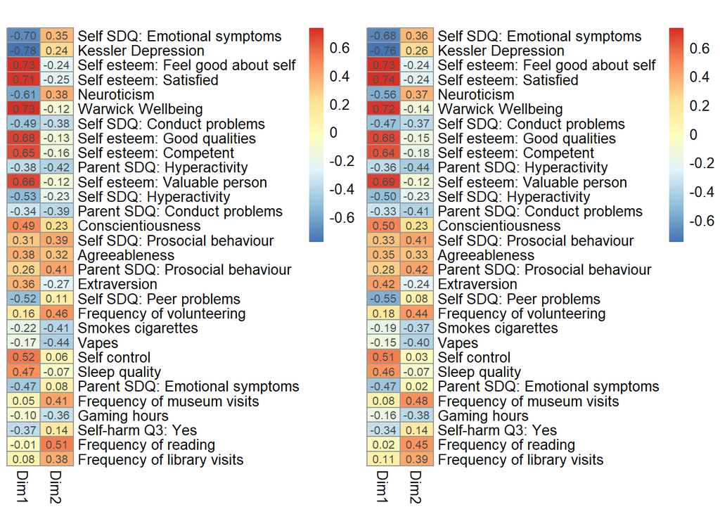

```r
Fig02a_plot <-  plot_mds_variable_correlations(
  mds_train = dat_imputed_highSMA_train_mds$points,
  mds_test  = dat_imputed_highSMA_test_mds_points,
  vars_train = dplyr::select(dat_imputed_highSMA_train, -mcsid_cm),
  vars_test  = dplyr::select(dat_imputed_highSMA_test, -mcsid_cm),
  title_train = "",
  title_test  = "",
  top_n = 30,
  rename_vars = TRUE,
  var_name_map =
    var_renames
  )$p_test
```

[figure not shown]

```r
ggsave("figures/Fig02a.pdf", plot = Fig02a_plot, bg = "white", width = 7, height = 4.5, units = "in")

FigS03b_plot <-  plot_mds_variable_correlations(
  mds_train = dat_imputed_highSMA_train_mds$points,
  mds_test  = dat_imputed_highSMA_test_mds_points,
  vars_train = dplyr::select(dat_imputed_highSMA_train, -mcsid_cm),
  vars_test  = dplyr::select(dat_imputed_highSMA_test, -mcsid_cm),
  title_train = "",
  title_test  = "",
  rename_vars = TRUE,
  var_name_map =
    var_renames
)$p_test
```

```r
ggsave("figures/FigS03b.pdf", plot = FigS03b_plot, bg = "white",  width = 7, height = 20, units = "in")
```

Now we apply Gaussian mixture modelling to cluster each dataset. Note that we relabel all clusters so that cluster 1 has highest wellbeing, to ease comparability across datasets. In each case, we extract the cluster boundaries from the training dataset, and use the boundaries in the testing dataset.

```r
# Perform GMM

set.seed(57)

# Fit GMM models

dat_imputed_all_train_gmm2     <- Mclust(dat_imputed_all_train_mds$points, G = 2)
dat_imputed_all_test_gmm2      <- predict(dat_imputed_all_train_gmm2, newdata = dat_imputed_all_test_mds_points)

dat_imputed_highSMA_train_gmm3 <- Mclust(dat_imputed_highSMA_train_mds$points,  G = 3)
dat_imputed_highSMA_test_gmm3  <- predict(dat_imputed_highSMA_train_gmm3, newdata = dat_imputed_highSMA_test_mds_points)

# Relabel all so that Cluster 1 has highest wellbeing

dat_imputed_all_train_gmm2 <- relabel_gmm_by_wellbeing(
  dat_imputed_all_train_mds$points,
  dat_imputed_all_train_gmm2,
  warwick_wellbeing = dat_imputed_all_train$warwick_wellbeing,
  G = 2
)

dat_imputed_all_test_gmm2 <- relabel_gmm_by_wellbeing(
  dat_imputed_all_test_mds_points,
  dat_imputed_all_test_gmm2,
  warwick_wellbeing = dat_imputed_all_test$warwick_wellbeing,
  G = 2
)

dat_imputed_highSMA_train_gmm3 <- relabel_gmm_by_wellbeing(
  dat_imputed_highSMA_train_mds$points,
  dat_imputed_highSMA_train_gmm3,
  warwick_wellbeing = dat_imputed_highSMA_train$warwick_wellbeing,
  G = 3
)

dat_imputed_highSMA_test_gmm3 <- relabel_gmm_by_wellbeing(
  dat_imputed_highSMA_test_mds_points,
  dat_imputed_highSMA_test_gmm3,
  warwick_wellbeing = dat_imputed_highSMA_test$warwick_wellbeing,
  G = 3
)
```

Report results:

```r
# ===============================
# Collect all outputs
# ===============================

output <- ""

# --- ALL ---
output <- paste0(output,
  report_clusters(dat_imputed_all_train_gmm2, dat_imputed_all_test_gmm2,
                  dat_imputed_all_train, dat_imputed_all_test,
                  "all gmm2"),
  report_silhouette(dat_imputed_all_train_gmm2, dat_imputed_all_test_gmm2,
                    dat_imputed_all_train_mds, dat_imputed_all_test_mds_points,
                    "all gmm2")
)

# --- highSMA gmm3 ---
output <- paste0(output,
  report_clusters(dat_imputed_highSMA_train_gmm3, dat_imputed_highSMA_test_gmm3,
                  dat_imputed_highSMA_train, dat_imputed_highSMA_test,
                  "highSMA gmm3"),
  report_silhouette(dat_imputed_highSMA_train_gmm3, dat_imputed_highSMA_test_gmm3,
                    dat_imputed_highSMA_train_mds, dat_imputed_highSMA_test_mds_points,
                    "highSMA gmm3")
)


# ===============================
# Print all at once
# ===============================
cat(output)
```

```
##
## ----- all gmm2 -----
## Train all gmm2, cluster 1 N: 3375 out of 3968 (85.06%)
## Train all gmm2, cluster 2 N: 593 out of 3968 (14.94%)
##
## Test all gmm2, cluster 1 N: 2324 out of 2706 (85.88%)
## Test all gmm2, cluster 2 N: 382 out of 2706 (14.12%)
##
##
## ===== Silhouette results for all gmm2 =====
## Train silhouette (crisp): 0.4209
## Train silhouette (fuzzy): 0.658
##
## Test silhouette (crisp): 0.3972
## Test silhouette (fuzzy): 0.634
##
##
##
## ----- highSMA gmm3 -----
## Train highSMA gmm3, cluster 1 N: 1425 out of 1910 (74.61%)
## Train highSMA gmm3, cluster 2 N: 187 out of 1910 (9.79%)
## Train highSMA gmm3, cluster 3 N: 298 out of 1910 (15.6%)
##
## Test highSMA gmm3, cluster 1 N: 955 out of 1292 (73.92%)
## Test highSMA gmm3, cluster 2 N: 126 out of 1292 (9.75%)
## Test highSMA gmm3, cluster 3 N: 211 out of 1292 (16.33%)
##
##
## ===== Silhouette results for highSMA gmm3 =====
## Train silhouette (crisp): 0.3825
## Train silhouette (fuzzy): 0.6475
##
## Test silhouette (crisp): 0.3605
## Test silhouette (fuzzy): 0.6206
```

Now we visualise the results, for each of the four in turn.

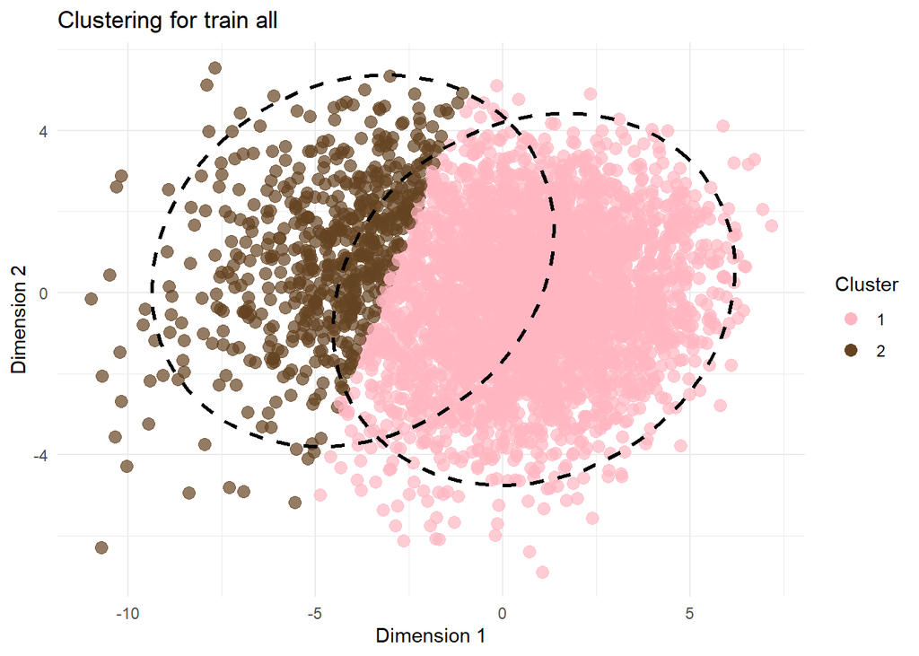

```r
plot_clusters_train_all <- plot_mds_clusters(mds_result = dat_imputed_all_train_mds$points,
                                             gmm_model_points  = dat_imputed_all_train_gmm2,
                                             gmm_model_ellipses  = dat_imputed_all_train_gmm2,

                                             title  = "Clustering for train all",
                                             cluster_colours = all_cluster_colours

                                             )

plot_clusters_train_all
```

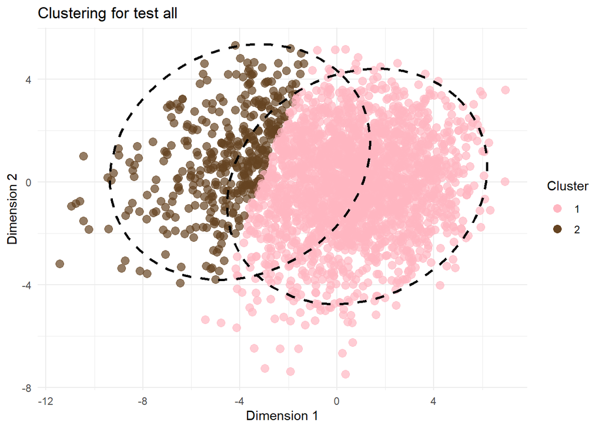

```r
plot_clusters_test_all <- plot_mds_clusters(mds_result = dat_imputed_all_test_mds_points,
                                             gmm_model_points = dat_imputed_all_test_gmm2,
                                            gmm_model_ellipses = dat_imputed_all_train_gmm2,
                                             title  = "Clustering for test all",
                                            cluster_colours = all_cluster_colours

                                             )

plot_clusters_test_all
```

```r
FigS02b_plot <- plot_clusters_test_all

ggsave("figures/FigS02b.pdf", plot = FigS02b_plot, bg = "white", width = 14, height = 9, units = "in")
```

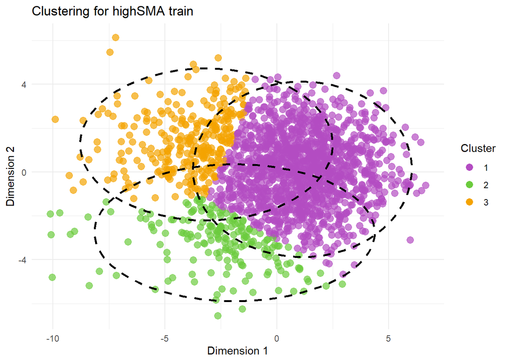

```r
plot_clusters_highSMA_train_gmm3 <- plot_mds_clusters(mds_result = dat_imputed_highSMA_train_mds$points,
                                             gmm_model_points = dat_imputed_highSMA_train_gmm3,
                                             gmm_model_ellipses = dat_imputed_highSMA_train_gmm3,
                                             title  = "Clustering for highSMA train",
                                             cluster_colours = highSMA_cluster_colours

                                             )

plot_clusters_highSMA_train_gmm3
```

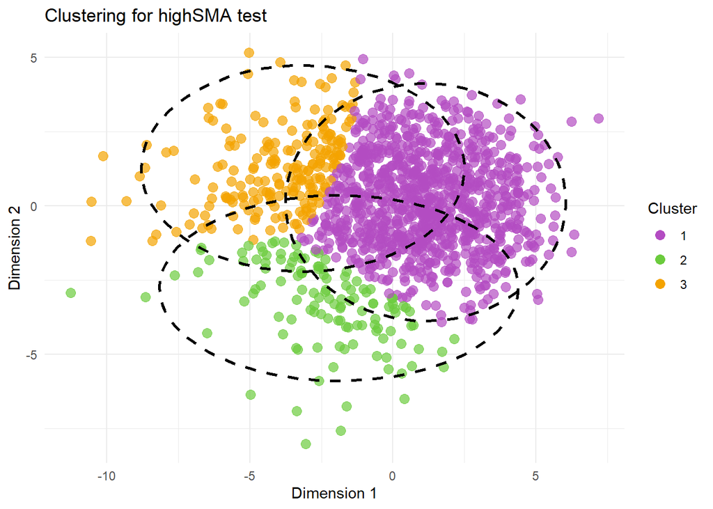

```r
plot_clusters_highSMA_test_gmm3 <- plot_mds_clusters(mds_result = dat_imputed_highSMA_test_mds_points,
                                             gmm_model_points = dat_imputed_highSMA_test_gmm3,
                                             gmm_model_ellipses = dat_imputed_highSMA_train_gmm3,
                                             title  = "Clustering for highSMA test",
                                               cluster_colours = highSMA_cluster_colours

                                             )

plot_clusters_highSMA_test_gmm3
```

```r
Fig02b_plot <- plot_mds_clusters(mds_result = dat_imputed_highSMA_test_mds_points,
                                             gmm_model_points = dat_imputed_highSMA_test_gmm3,
                                 gmm_model_ellipses = dat_imputed_highSMA_train_gmm3,
                                             title  = "",
                                               cluster_colours = highSMA_cluster_colours

                                             )

ggsave("figures/Fig02b.pdf", plot = Fig02b_plot, bg = "white", width = 14, height = 9, units = "in")
```

In RQ2 we said we would analyse how cluster membership across all clusters relates to SMA level. We do that here:

```r
### ===============================
### 1. Train chi-square test
### ===============================
dat_imputed_train_all_cluster_SMA <- data.frame(
  cluster  = dat_imputed_all_train_gmm2$classification,
  mcsid_cm = dat_imputed_all_train$mcsid_cm) %>%
  left_join(mcsid_cm_SMA, by= "mcsid_cm") %>%
  filter(!is.na(sma))

table_full_train <- table(dat_imputed_train_all_cluster_SMA$cluster,
                          dat_imputed_train_all_cluster_SMA$sma)
chi_train <- chisq.test(table_full_train)

### ===============================
### 2. Test chi-square test
### ===============================
dat_imputed_test_all_cluster_SMA <- data.frame(
  cluster  = dat_imputed_all_test_gmm2$classification,
  mcsid_cm = dat_imputed_all_test$mcsid_cm) %>%
  left_join(mcsid_cm_SMA, by= "mcsid_cm") %>%
  filter(!is.na(sma))

# contingency table: clusters × SMA
table_full_test <- table(dat_imputed_test_all_cluster_SMA$cluster,
                         dat_imputed_test_all_cluster_SMA$sma)

chi_test <- chisq.test(table_full_test)

# Run one test per SMA category (i.e., compare clusters for each SMA)
posthoc_results <- lapply(colnames(table_full_test), function(sma_level) {
  counts <- table_full_test[, sma_level]              # counts per cluster for this SMA
  totals <- rowSums(table_full_test)                  # total per cluster
  test   <- prop.test(counts, totals)                 # chi-square test of equal proportions
  list(sma = sma_level, test = test)
})

# Show results
posthoc_results
```

```
## [[1]]
## [[1]]$sma
## [1] "Agree"
##
## [[1]]$test
##
##  2-sample test for equality of proportions with continuity correction
##
## data:  counts out of totals
## X-squared = 0.52045, df = 1, p-value = 0.4707
## alternative hypothesis: two.sided
## 95 percent confidence interval:
##  -0.07537120  0.03359932
## sample estimates:
##    prop 1    prop 2
## 0.3796376 0.4005236
##
##
##
## [[2]]
## [[2]]$sma
## [1] "Disagree"
##
## [[2]]$test
##
##  2-sample test for equality of proportions with continuity correction
##
## data:  counts out of totals
## X-squared = 1.0123, df = 1, p-value = 0.3143
## alternative hypothesis: two.sided
## 95 percent confidence interval:
##  -0.02546603  0.08321124
## sample estimates:
##    prop 1    prop 2
## 0.4163072 0.3874346
##
##
##
## [[3]]
## [[3]]$sma
```

[output cut: 18 more lines]

```
## [[4]]$sma
## [1] "Strongly disagree"
##
## [[4]]$test
##
##  2-sample test for equality of proportions with continuity correction
##
## data:  counts out of totals
## X-squared = 3.2834, df = 1, p-value = 0.06998
## alternative hypothesis: two.sided
## 95 percent confidence interval:
##  0.0009312133 0.0645476929
## sample estimates:
##     prop 1     prop 2
## 0.11389129 0.08115183
```

```r
### ===============================
### 3. Print chi-square results
### ===============================
cat("===== Chi-square SMA vs Cluster =====\n\n",
    "Train set:\n", capture.output(chi_train), "\n\n",
    "Test set:\n", capture.output(chi_test), "\n\n")
```

```
## ===== Chi-square SMA vs Cluster =====
##
##  Train set:
##      Pearson's Chi-squared test  data:  table_full_train X-squared = 8.2933, df = 3, p-value = 0.04032
##
##  Test set:
##      Pearson's Chi-squared test  data:  table_full_test X-squared = 9.925, df = 3, p-value = 0.01921
```

```r
### ===============================
### 4. Plot SMA response proportions
### ===============================
sma_plot_train_data <- dat_imputed_train_all_cluster_SMA %>%
  group_by(cluster, sma) %>%
  summarise(n = n(), .groups = 'drop') %>%
  group_by(cluster) %>%
  mutate(proportion = n / sum(n)) %>%
  mutate(sma = factor(sma,
                      levels = c("Strongly disagree", "Disagree", "Agree", "Strongly agree")))


sma_plot_test_data <- dat_imputed_test_all_cluster_SMA %>%
  group_by(cluster, sma) %>%
  summarise(n = n(), .groups = 'drop') %>%
  group_by(cluster) %>%
  mutate(proportion = n / sum(n)) %>%
  mutate(sma = factor(sma,
                      levels = c("Strongly disagree", "Disagree", "Agree", "Strongly agree")))

FigS02c_plot <- ggplot(sma_plot_test_data, aes(x = sma, y = proportion,
                                          group = factor(cluster),
                                          color = factor(cluster))) +
  geom_point(size = 3) +
  geom_line(linewidth = 1) +
  labs(x = "SMA Response", y = "Proportion", color = "Cluster") +
  scale_color_manual(values = all_cluster_colours) +
  theme_minimal()

ggsave("figures/FigS02c.pdf", plot = FigS02c_plot, bg = "white", width = 6, height = 8, units = "in")
```

Now we do a series of elastic net regularised regression to establish 1) which variables predict SMA level across the population (RQ2iii) and 2) which variables predict membership of each of the three high SMA clusters a) vs. each other and b) vs. low SMA.

To do that, we first prepare the datasets from which we will do the regression.

```r
sma_levels <- c("Strongly disagree", "Disagree", "Agree", "Strongly agree")

dat_all_xtrain <- dplyr::select(dat_imputed_SMA_train, -mcsid_cm, -sma)
dat_all_xtest  <- dplyr::select(dat_imputed_SMA_test, -mcsid_cm, -sma)

dat_highSMA_xtrain <- dplyr::select(dat_imputed_SMA_train, -mcsid_cm) %>%
    filter(sma == "Agree" | sma == "Strongly agree") %>%
  dplyr::select(-sma)
dat_highSMA_xtest  <- dplyr::select(dat_imputed_SMA_test, -mcsid_cm) %>%
    filter(sma == "Agree" | sma == "Strongly agree") %>%
  dplyr::select(-sma)

## clusters - TRAIN
dat_imputed_highSMA_train_clust              <- dat_imputed_highSMA_train
dat_imputed_highSMA_train_clust$gmm3_cluster <- dat_imputed_highSMA_train_gmm3$classification

dat_imputed_all_train_clust <- dplyr::select(dat_imputed_SMA_train, -sma) %>%
  left_join(
    dplyr::select(dat_imputed_highSMA_train_clust, mcsid_cm, gmm3_cluster),
    by = "mcsid_cm"
  ) %>%
  mutate(
         gmm3_cluster = ifelse(is.na(gmm3_cluster), 0, as.character(gmm3_cluster))
         ) %>%
  select(-mcsid_cm)

## clusters - TEST
dat_imputed_highSMA_test_clust              <- dat_imputed_highSMA_test
dat_imputed_highSMA_test_clust$gmm3_cluster <- dat_imputed_highSMA_test_gmm3$classification


dat_imputed_all_test_clust <- dplyr::select(dat_imputed_SMA_test, -sma) %>%
  left_join(
    dplyr::select(dat_imputed_highSMA_test_clust, mcsid_cm, gmm3_cluster),
    by = "mcsid_cm"
  ) %>%
  mutate(
         gmm3_cluster = ifelse(is.na(gmm3_cluster), 0, as.character(gmm3_cluster))
         ) %>%
  select(-mcsid_cm)
```

Run regression, starting with all, predicting SMA.

```r
dat_all_SMA_ytrain <- dat_imputed_SMA_train %>%
    pull(sma) %>%
    factor(levels = sma_levels, ordered = TRUE) %>%
    as.numeric()
dat_all_SMA_ytest <- dat_imputed_SMA_test %>%
    pull(sma) %>%
    factor(levels = sma_levels, ordered = TRUE) %>%
    as.numeric()

## run on training dataset to select optimal lambda value and get selected predictors

fit_all_SMA <- cv.glmnet(
  as.matrix(dat_all_xtrain), as.matrix(dat_all_SMA_ytrain),
  type.measure = "mse",
  alpha        = 0.5,
  family       = "gaussian"
)

results_all_SMA <- bootstrap_feature_importance_wrapper(
  dat_all_xtrain, dat_all_SMA_ytrain,
  dat_all_xtest, dat_all_SMA_ytest,
  alpha_val = 0.5, fit_all_SMA$lambda.1se,
    colours = c("#2166AC", "#A52A2A" ),
  family = "gaussian"
)
```

```
## Bootstrap iteration: 1 / 1000
```

```
## Bootstrap iteration: 100 / 1000
```

```
## Bootstrap iteration: 200 / 1000
```

```
## Bootstrap iteration: 300 / 1000
```

```
## Bootstrap iteration: 400 / 1000
```

```
## Bootstrap iteration: 500 / 1000
```

```
## Bootstrap iteration: 600 / 1000
```

```
## Bootstrap iteration: 700 / 1000
```

```
## Bootstrap iteration: 800 / 1000
```

```
## Bootstrap iteration: 900 / 1000
```

```
## Bootstrap iteration: 1000 / 1000
```

```
## Bootstrap iteration: 1 / 1000
```

```
## Bootstrap iteration: 100 / 1000
```

```
## Bootstrap iteration: 200 / 1000
```

```
## Bootstrap iteration: 300 / 1000
```

```
## Bootstrap iteration: 400 / 1000
```

```
## Bootstrap iteration: 500 / 1000
```

```
## Bootstrap iteration: 600 / 1000
```

```
## Bootstrap iteration: 700 / 1000
```

```
## Bootstrap iteration: 800 / 1000
```

```
## Bootstrap iteration: 900 / 1000
```

```
## Bootstrap iteration: 1000 / 1000
```

```
## Bootstrap iteration: 1 / 1000
```

```
## Bootstrap iteration: 100 / 1000
```

```
## Bootstrap iteration: 200 / 1000
```

```
## Bootstrap iteration: 300 / 1000
```

```
## Bootstrap iteration: 400 / 1000
```

```
## Bootstrap iteration: 500 / 1000
```

```
## Bootstrap iteration: 600 / 1000
```

```
## Bootstrap iteration: 700 / 1000
```

```
## Bootstrap iteration: 800 / 1000
```

```
## Bootstrap iteration: 900 / 1000
```

```
## Bootstrap iteration: 1000 / 1000
```

```r
# Access tables
results_all_SMA$train$summary
```

```
## # A tibble: 9 × 6
##   feature                     mean   lower   upper prop_nonzero direction
##   <chr>                      <dbl>   <dbl>   <dbl>        <dbl> <chr>
## 1 activity_friends          0.0380  0.0118  0.0668        0.997 positive
## 2 activity_party            0.0811  0.0520  0.110         1     positive
## 3 activity_read            -0.0650 -0.0899 -0.0387        1     negative
## 4 cm_sdq_emotion            0.0508  0.0138  0.0877        0.997 positive
## 5 personality_extravert     0.0717  0.0446  0.100         1     positive
## 6 personality_neurot        0.0559  0.0201  0.0926        0.997 positive
## 7 self_control             -0.0834 -0.114  -0.0567        1     negative
## 8 television_hrs            0.0587  0.0314  0.0843        1     positive
## 9 victimisation_gossip_Yes  0.0666  0.0149  0.115         0.997 positive
```

```r
results_all_SMA$test_all$summary
```

```
## # A tibble: 11 × 6
##    feature                      mean    lower    upper prop_nonzero direction
##    <chr>                       <dbl>    <dbl>    <dbl>        <dbl> <chr>
##  1 activity_friends           0.0401  0.00807  0.0689         0.998 positive
##  2 activity_party             0.0434  0.00852  0.0782         0.993 positive
##  3 activity_read             -0.0586 -0.0901  -0.0275         1     negative
##  4 gaming_hrs                -0.0354 -0.0681  -0.00226        0.983 negative
##  5 personality_conscientious -0.0343 -0.0647  -0.00383        0.986 negative
##  6 personality_extravert      0.0969  0.0657   0.129          1     positive
##  7 personality_neurot         0.0421  0        0.0810         0.968 positive
##  8 self_control              -0.0920 -0.126   -0.0606         1     negative
##  9 television_hrs             0.0628  0.0321   0.0928         1     positive
## 10 victimisation_gossip_Yes   0.0565  0        0.120          0.956 positive
## 11 victimisation_harass_Yes   0.0818  0        0.174          0.963 positive
```

```r
results_all_SMA$test_restricted$summary
```

```
## # A tibble: 9 × 6
##   feature                     mean    lower   upper prop_nonzero direction
##   <chr>                      <dbl>    <dbl>   <dbl>        <dbl> <chr>
## 1 activity_friends          0.0464  0.0157   0.0756        0.999 positive
## 2 activity_party            0.0591  0.0247   0.0922        1     positive
## 3 activity_read            -0.0601 -0.0898  -0.0296        1     negative
## 4 cm_sdq_emotion            0.0380  0        0.0857        0.952 positive
## 5 personality_extravert     0.112   0.0815   0.143         1     positive
## 6 personality_neurot        0.0485  0.00342  0.0904        0.983 positive
## 7 self_control             -0.105  -0.137   -0.0734        1     negative
## 8 television_hrs            0.0607  0.0312   0.0916        1     positive
## 9 victimisation_gossip_Yes  0.0799  0.0207   0.142         0.994 positive
```

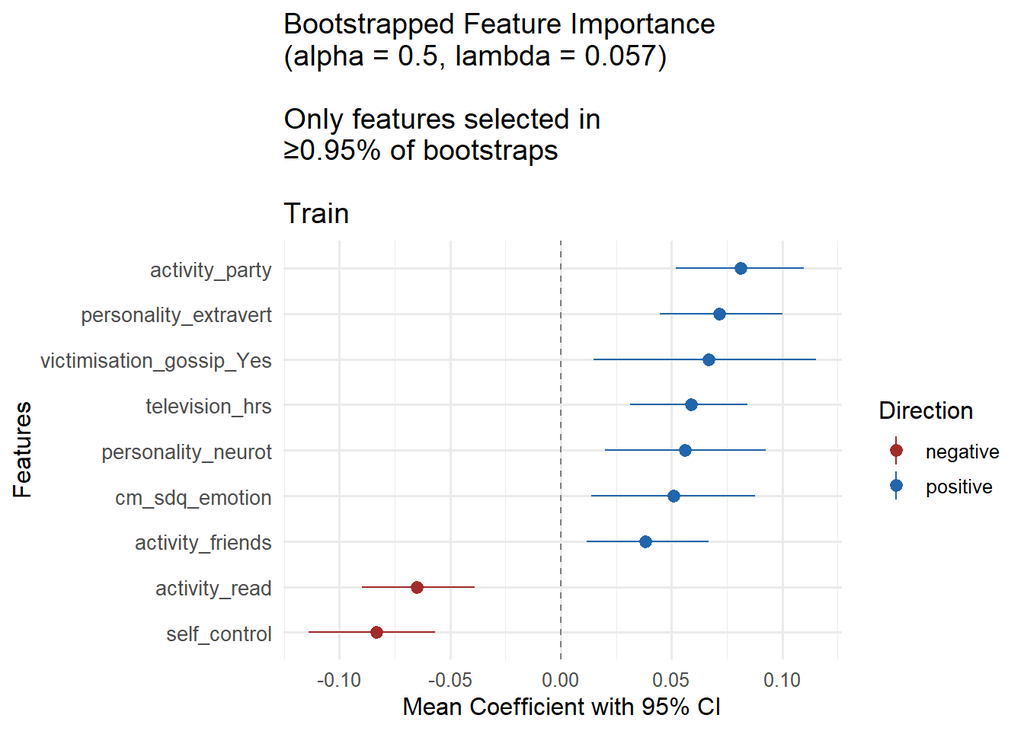

```r
# Print plots
print(results_all_SMA$train$plot)
```

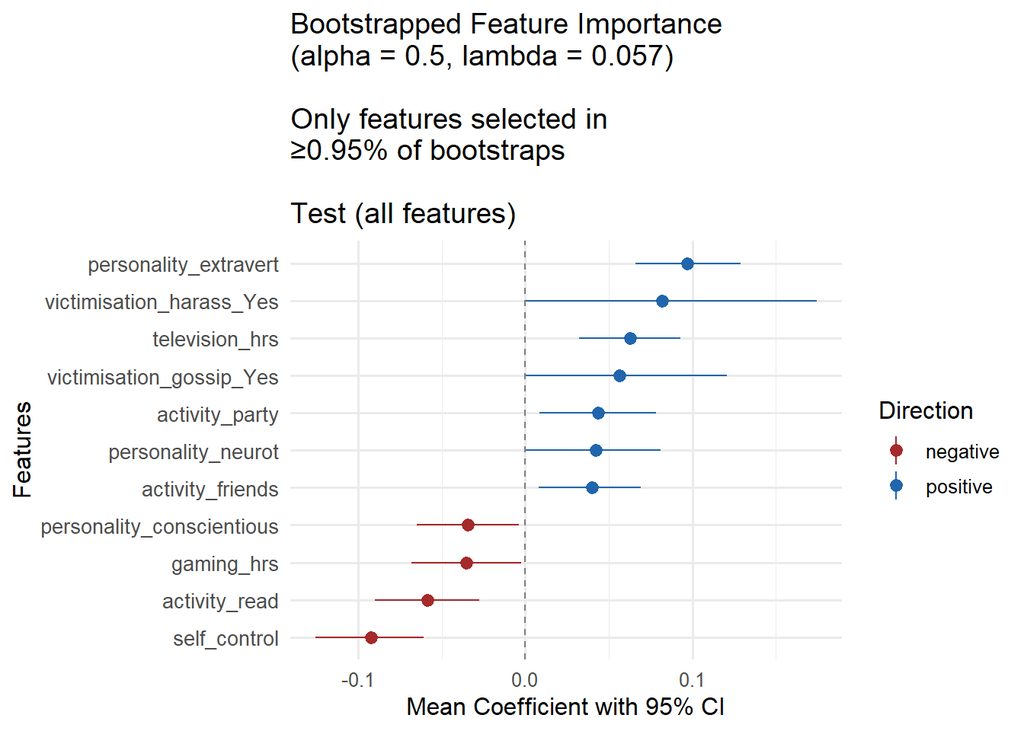

```r
print(results_all_SMA$test_all$plot)
```

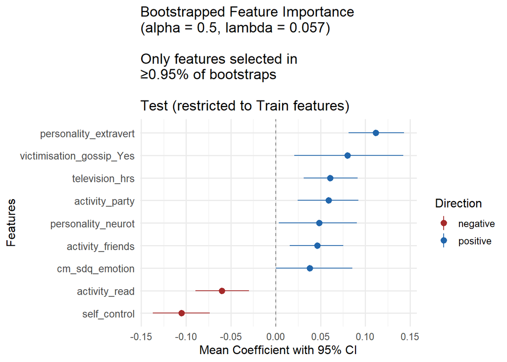

```r
print(results_all_SMA$test_restricted$plot)
```

```r
Fig01b_plot <- results_all_SMA$test_restricted$plot +
  scale_x_discrete(
    labels = var_renames
  ) +
  scale_color_manual(
    values = c("positive" = "#A52A2A", "negative" = "#2166AC")
  ) +
  labs(
    title = ""
  )
ggsave("figures/Fig01b.pdf", plot = Fig01b_plot, bg = "white", width = 7, height = 4.5, units = "in")
```

As an exploratory analysis, we want to understand the behavioural-emotional make-up of each cluster. To do so, we use elastic net regularised regression to predict membership of each cluster (1) compared to those within other SMA clusters, and (2) compared to those without SMA.

1. We begin by using regression to predict membership of each cluster compared to other clusters within the SMA group:

```r
dat_highSMA_gmm3probC1_ytrain <- dat_imputed_highSMA_train_gmm3$z[,1]
dat_highSMA_gmm3probC1_ytest  <- dat_imputed_highSMA_test_gmm3$z[,1]

dat_highSMA_gmm3probC2_ytrain <- dat_imputed_highSMA_train_gmm3$z[,2]
dat_highSMA_gmm3probC2_ytest  <- dat_imputed_highSMA_test_gmm3$z[,2]

dat_highSMA_gmm3probC3_ytrain <- dat_imputed_highSMA_train_gmm3$z[,3]
dat_highSMA_gmm3probC3_ytest  <- dat_imputed_highSMA_test_gmm3$z[,3]


## get optimal lambda

fit_highSMA_gmm3probC1 <- cv.glmnet(
  as.matrix(dat_highSMA_xtrain), as.matrix(dat_highSMA_gmm3probC1_ytrain),
  type.measure = "mse",
  alpha        = 0.5,
  family       = "gaussian"
)

fit_highSMA_gmm3probC2 <- cv.glmnet(
  as.matrix(dat_highSMA_xtrain), as.matrix(dat_highSMA_gmm3probC2_ytrain),
  type.measure = "mse",
  alpha        = 0.5,
  family       = "gaussian"
)

fit_highSMA_gmm3probC3 <- cv.glmnet(
  as.matrix(dat_highSMA_xtrain), as.matrix(dat_highSMA_gmm3probC3_ytrain),
  type.measure = "mse",
  alpha        = 0.5,
  family       = "gaussian"
)

# run bootstraps

### cluster 1

results_highSMA_gmm3probC1 <- bootstrap_feature_importance_wrapper(
  dat_highSMA_xtrain, dat_highSMA_gmm3probC1_ytrain,
  dat_highSMA_xtest, dat_highSMA_gmm3probC1_ytest,
  alpha_val = 0.5, fit_highSMA_gmm3probC1$lambda.1se,
  n_bootstrap = 1000,
  colours = c("purple", "darkgreen"),
  family = "gaussian"
)
```

```
## Bootstrap iteration: 1 / 1000
```

```
## Bootstrap iteration: 100 / 1000
```

```
## Bootstrap iteration: 200 / 1000
```

```
## Bootstrap iteration: 300 / 1000
```

```
## Bootstrap iteration: 400 / 1000
```

```
## Bootstrap iteration: 500 / 1000
```

```
## Bootstrap iteration: 600 / 1000
```

```
## Bootstrap iteration: 700 / 1000
```

```
## Bootstrap iteration: 800 / 1000
```

```
## Bootstrap iteration: 900 / 1000
```

```
## Bootstrap iteration: 1000 / 1000
```

```
## Bootstrap iteration: 1 / 1000
```

```
## Bootstrap iteration: 100 / 1000
```

```
## Bootstrap iteration: 200 / 1000
```

```
## Bootstrap iteration: 300 / 1000
```

```
## Bootstrap iteration: 400 / 1000
```

```
## Bootstrap iteration: 500 / 1000
```

```
## Bootstrap iteration: 600 / 1000
```

```
## Bootstrap iteration: 700 / 1000
```

```
## Bootstrap iteration: 800 / 1000
```

```
## Bootstrap iteration: 900 / 1000
```

```
## Bootstrap iteration: 1000 / 1000
```

```
## Bootstrap iteration: 1 / 1000
```

```
## Bootstrap iteration: 100 / 1000
```

```
## Bootstrap iteration: 200 / 1000
```

```
## Bootstrap iteration: 300 / 1000
```

```
## Bootstrap iteration: 400 / 1000
```

```
## Bootstrap iteration: 500 / 1000
```

```
## Bootstrap iteration: 600 / 1000
```

```
## Bootstrap iteration: 700 / 1000
```

```
## Bootstrap iteration: 800 / 1000
```

```
## Bootstrap iteration: 900 / 1000
```

```
## Bootstrap iteration: 1000 / 1000
```

```r
# Access tables
results_highSMA_gmm3probC1$train$summary
```

```
## # A tibble: 29 × 6
##    feature              mean    lower    upper prop_nonzero direction
##    <chr>               <dbl>    <dbl>    <dbl>        <dbl> <chr>
##  1 activity_museum   0.00817  0.00100  0.0152         0.988 positive
##  2 cm_sdq_conduct   -0.0227  -0.0318  -0.0137         1     negative
##  3 cm_sdq_emotion   -0.0297  -0.0394  -0.0200         1     negative
##  4 cm_sdq_hyper     -0.0208  -0.0301  -0.0117         1     negative
##  5 cm_sdq_peer      -0.0119  -0.0195  -0.00404        0.999 negative
##  6 cm_sdq_prosoc     0.0170   0.00799  0.0260         1     positive
##  7 kessl_depression -0.0481  -0.0586  -0.0377         1     negative
##  8 pa_sdq_conduct   -0.0170  -0.0272  -0.00729        1     negative
##  9 pa_sdq_emotion   -0.0211  -0.0299  -0.0116         1     negative
## 10 pa_sdq_hyper     -0.0221  -0.0313  -0.0127         1     negative
## # ℹ 19 more rows
```

```r
results_highSMA_gmm3probC1$test_all$summary
```

```
## # A tibble: 23 × 6
##    feature               mean     lower    upper prop_nonzero direction
##    <chr>                <dbl>     <dbl>    <dbl>        <dbl> <chr>
##  1 activity_religious  0.0110  0.00316   0.0187         0.997 positive
##  2 cm_sdq_conduct     -0.0208 -0.0305   -0.0114         1     negative
##  3 cm_sdq_emotion     -0.0272 -0.0385   -0.0152         1     negative
##  4 cm_sdq_hyper       -0.0109 -0.0201   -0.00103        0.985 negative
##  5 cm_sdq_peer        -0.0199 -0.0301   -0.0104         1     negative
##  6 cm_sdq_prosoc       0.0105  0.000335  0.0214         0.979 positive
##  7 kessl_depression   -0.0467 -0.0584   -0.0347         1     negative
##  8 pa_sdq_conduct     -0.0224 -0.0345   -0.00993        0.999 negative
##  9 pa_sdq_emotion     -0.0199 -0.0309   -0.00884        1     negative
## 10 pa_sdq_hyper       -0.0276 -0.0384   -0.0153         1     negative
## # ℹ 13 more rows
```

```r
results_highSMA_gmm3probC1$test_restricted$summary
```

```
## # A tibble: 21 × 6
##    feature              mean    lower     upper prop_nonzero direction
##    <chr>               <dbl>    <dbl>     <dbl>        <dbl> <chr>
##  1 activity_museum   0.00804  0        0.0163          0.966 positive
##  2 cm_sdq_conduct   -0.0225  -0.0322  -0.0123          1     negative
##  3 cm_sdq_emotion   -0.0259  -0.0374  -0.0135          1     negative
##  4 cm_sdq_hyper     -0.0105  -0.0202  -0.000333        0.978 negative
##  5 cm_sdq_peer      -0.0218  -0.0327  -0.0117          1     negative
##  6 cm_sdq_prosoc     0.0148   0.00364  0.0261          0.996 positive
##  7 kessl_depression -0.0485  -0.0597  -0.0367          1     negative
##  8 pa_sdq_conduct   -0.0242  -0.0369  -0.0115          1     negative
##  9 pa_sdq_emotion   -0.0198  -0.0308  -0.00841         1     negative
## 10 pa_sdq_hyper     -0.0309  -0.0428  -0.0184          1     negative
## # ℹ 11 more rows
```

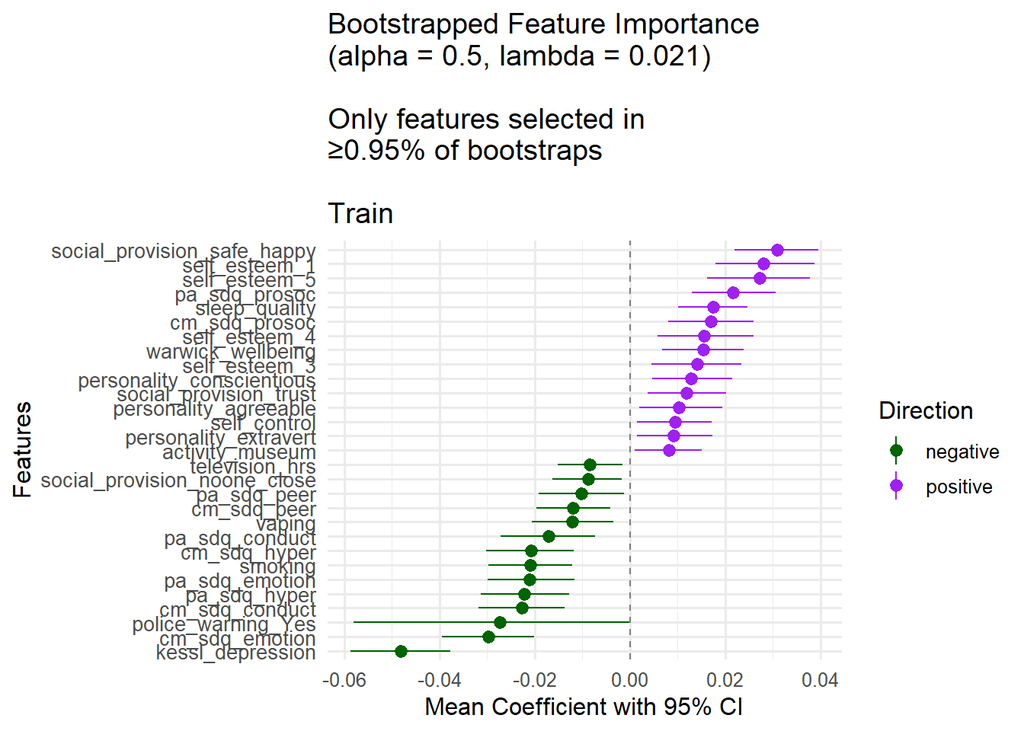

```r
# Print plots
print(results_highSMA_gmm3probC1$train$plot)
```

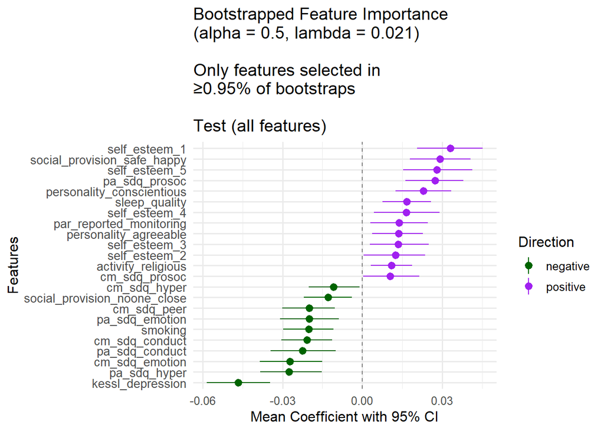

```r
print(results_highSMA_gmm3probC1$test_all$plot)
```

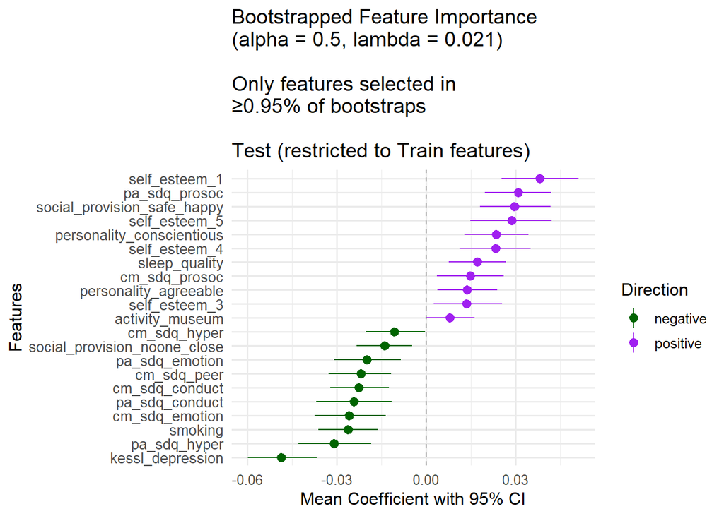

```r
print(results_highSMA_gmm3probC1$test_restricted$plot)
```

```r
### cluster 2

results_highSMA_gmm3probC2 <- bootstrap_feature_importance_wrapper(
  dat_highSMA_xtrain, dat_highSMA_gmm3probC2_ytrain,
  dat_highSMA_xtest, dat_highSMA_gmm3probC2_ytest,
  alpha_val = 0.5, fit_highSMA_gmm3probC2$lambda.1se,
  n_bootstrap = 1000,
  colours = c("purple", "darkgreen"),
  family = "gaussian"
)
```

```
## Bootstrap iteration: 1 / 1000
```

```
## Bootstrap iteration: 100 / 1000
```

```
## Bootstrap iteration: 200 / 1000
```

```
## Bootstrap iteration: 300 / 1000
```

```
## Bootstrap iteration: 400 / 1000
```

```
## Bootstrap iteration: 500 / 1000
```

```
## Bootstrap iteration: 600 / 1000
```

```
## Bootstrap iteration: 700 / 1000
```

```
## Bootstrap iteration: 800 / 1000
```

```
## Bootstrap iteration: 900 / 1000
```

```
## Bootstrap iteration: 1000 / 1000
```

```
## Bootstrap iteration: 1 / 1000
```

```
## Bootstrap iteration: 100 / 1000
```

```
## Bootstrap iteration: 200 / 1000
```

```
## Bootstrap iteration: 300 / 1000
```

```
## Bootstrap iteration: 400 / 1000
```

```
## Bootstrap iteration: 500 / 1000
```

```
## Bootstrap iteration: 600 / 1000
```

```
## Bootstrap iteration: 700 / 1000
```

```
## Bootstrap iteration: 800 / 1000
```

```
## Bootstrap iteration: 900 / 1000
```

```
## Bootstrap iteration: 1000 / 1000
```

```
## Bootstrap iteration: 1 / 1000
```

```
## Bootstrap iteration: 100 / 1000
```

```
## Bootstrap iteration: 200 / 1000
```

```
## Bootstrap iteration: 300 / 1000
```

```
## Bootstrap iteration: 400 / 1000
```

```
## Bootstrap iteration: 500 / 1000
```

```
## Bootstrap iteration: 600 / 1000
```

```
## Bootstrap iteration: 700 / 1000
```

```
## Bootstrap iteration: 800 / 1000
```

```
## Bootstrap iteration: 900 / 1000
```

```
## Bootstrap iteration: 1000 / 1000
```

```r
# Access tables
results_highSMA_gmm3probC2$train$summary
```

```
## # A tibble: 18 × 6
##    feature                       mean     lower     upper prop_nonzero direction
##    <chr>                        <dbl>     <dbl>     <dbl>        <dbl> <chr>
##  1 activity_library          -0.0131  -0.0189   -0.00757         0.999 negative
##  2 activity_museum           -0.0206  -0.0269   -0.0139          1     negative
##  3 activity_read             -0.0142  -0.0211   -0.00719         1     negative
##  4 activity_volunteering     -0.00794 -0.0140   -0.00197         0.995 negative
##  5 cm_sdq_conduct             0.0293   0.0209    0.0377          1     positive
##  6 cm_sdq_emotion            -0.00657 -0.0137    0               0.953 negative
##  7 cm_sdq_prosoc             -0.0210  -0.0298   -0.0133          1     negative
##  8 gaming_hrs                 0.00871  0.00158   0.0157          0.997 positive
##  9 pa_sdq_conduct             0.0304   0.0204    0.0404          1     positive
## 10 pa_sdq_hyper               0.0321   0.0235    0.0409          1     positive
## 11 pa_sdq_prosoc             -0.0320  -0.0409   -0.0227          1     negative
## 12 par_reported_monitoring   -0.0237  -0.0317   -0.0156          1     negative
## 13 personality_agreeable     -0.0139  -0.0214   -0.00591         1     negative
## 14 personality_conscientious -0.00746 -0.0150    0               0.966 negative
## 15 personality_open          -0.00715 -0.0140   -0.000486        0.98  negative
## 16 smoking                    0.0316   0.0220    0.0419          1     positive
## 17 television_hrs             0.00662  0.000440  0.0129          0.978 positive
## 18 vaping                     0.0325   0.0235    0.0417          1     positive
```

```r
results_highSMA_gmm3probC2$test_all$summary
```

```
## # A tibble: 17 × 6
##    feature                     mean    lower    upper prop_nonzero direction
##    <chr>                      <dbl>    <dbl>    <dbl>        <dbl> <chr>
##  1 activity_museum         -0.0141  -0.0219  -0.00708        1     negative
##  2 activity_party           0.00785  0        0.0164         0.954 positive
##  3 activity_read           -0.0151  -0.0230  -0.00700        1     negative
##  4 activity_religious      -0.0102  -0.0166  -0.00333        1     negative
##  5 activity_volunteering   -0.0143  -0.0211  -0.00773        1     negative
##  6 cm_sdq_conduct           0.0263   0.0162   0.0369         1     positive
##  7 cm_sdq_prosoc           -0.0202  -0.0308  -0.0102         1     negative
##  8 gaming_hrs               0.0153   0.00736  0.0231         0.999 positive
##  9 pa_sdq_conduct           0.0349   0.0236   0.0468         1     positive
## 10 pa_sdq_hyper             0.0273   0.0154   0.0382         1     positive
## 11 pa_sdq_prosoc           -0.0221  -0.0316  -0.0128         1     negative
## 12 par_reported_monitoring -0.0235  -0.0337  -0.0126         1     negative
## 13 par_reported_talking    -0.0139  -0.0236  -0.00519        0.999 negative
## 14 personality_agreeable   -0.0185  -0.0283  -0.00777        1     negative
## 15 police_warning_Yes       0.0352   0        0.0773         0.954 positive
## 16 smoking                  0.0273   0.0163   0.0385         1     positive
## 17 vaping                   0.0229   0.0120   0.0334         1     positive
```

```r
results_highSMA_gmm3probC2$test_restricted$summary
```

```
## # A tibble: 15 × 6
##    feature                     mean    lower    upper prop_nonzero direction
##    <chr>                      <dbl>    <dbl>    <dbl>        <dbl> <chr>
##  1 activity_museum         -0.0164  -0.0241  -0.00836        1     negative
##  2 activity_read           -0.0216  -0.0302  -0.0136         1     negative
##  3 activity_volunteering   -0.0172  -0.0241  -0.0103         1     negative
##  4 cm_sdq_conduct           0.0321   0.0218   0.0433         1     positive
##  5 cm_sdq_emotion          -0.0139  -0.0221  -0.00619        1     negative
##  6 cm_sdq_prosoc           -0.0194  -0.0306  -0.00882        0.999 negative
##  7 gaming_hrs               0.0155   0.00720  0.0241         0.999 positive
##  8 pa_sdq_conduct           0.0344   0.0225   0.0466         1     positive
##  9 pa_sdq_hyper             0.0289   0.0163   0.0402         1     positive
## 10 pa_sdq_prosoc           -0.0249  -0.0351  -0.0147         1     negative
## 11 par_reported_monitoring -0.0319  -0.0423  -0.0211         1     negative
## 12 personality_agreeable   -0.0192  -0.0292  -0.00826        1     negative
## 13 personality_open        -0.00678 -0.0147   0              0.957 negative
## 14 smoking                  0.0355   0.0236   0.0472         1     positive
## 15 vaping                   0.0279   0.0161   0.0398         1     positive
```

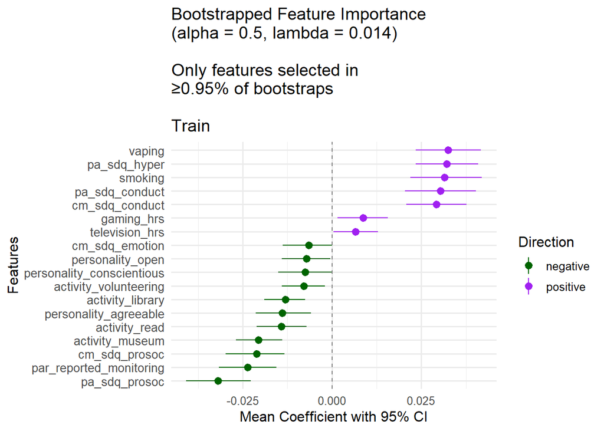

```r
# Print plots
print(results_highSMA_gmm3probC2$train$plot)
```

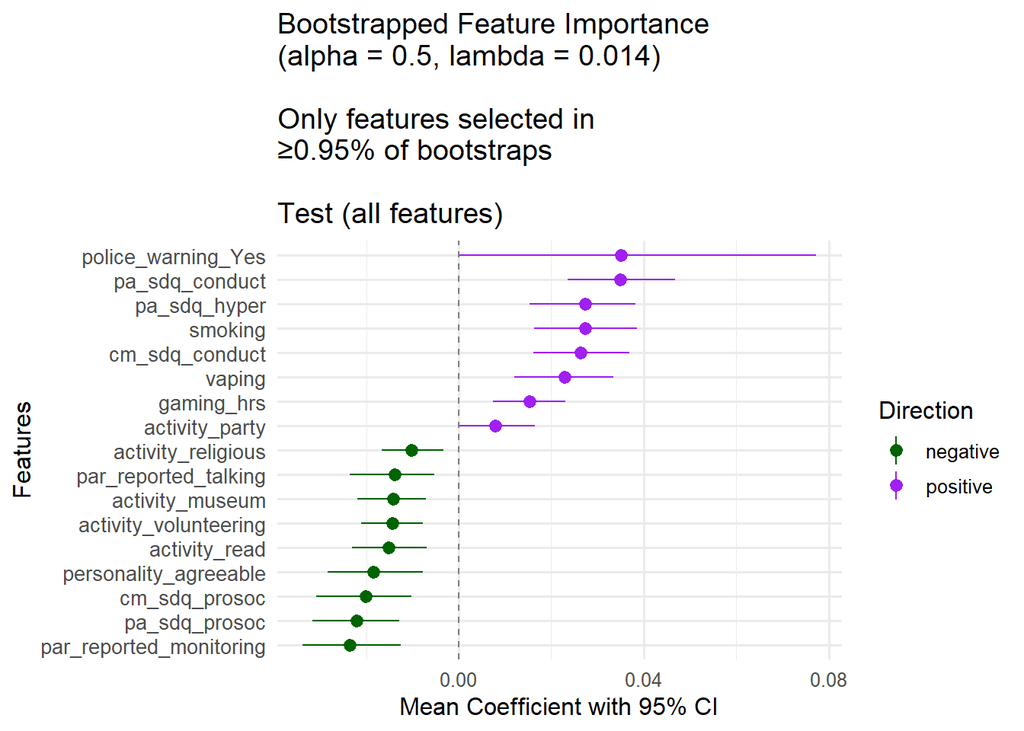

```r
print(results_highSMA_gmm3probC2$test_all$plot)
```

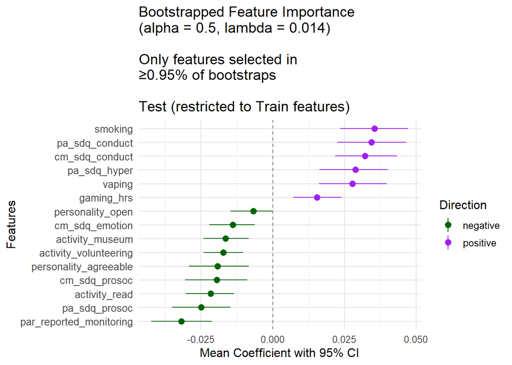

```r
print(results_highSMA_gmm3probC2$test_restricted$plot)
```

```r
### cluster 3

results_highSMA_gmm3probC3 <- bootstrap_feature_importance_wrapper(
  dat_highSMA_xtrain, dat_highSMA_gmm3probC3_ytrain,
  dat_highSMA_xtest, dat_highSMA_gmm3probC3_ytest,
  alpha_val = 0.5, fit_highSMA_gmm3probC3$lambda.1se,
  n_bootstrap = 1000,
  colours = c("purple", "darkgreen"),
  family = "gaussian"
)
```

```
## Bootstrap iteration: 1 / 1000
```

```
## Bootstrap iteration: 100 / 1000
```

```
## Bootstrap iteration: 200 / 1000
```

```
## Bootstrap iteration: 300 / 1000
```

```
## Bootstrap iteration: 400 / 1000
```

```
## Bootstrap iteration: 500 / 1000
```

```
## Bootstrap iteration: 600 / 1000
```

```
## Bootstrap iteration: 700 / 1000
```

```
## Bootstrap iteration: 800 / 1000
```

```
## Bootstrap iteration: 900 / 1000
```

```
## Bootstrap iteration: 1000 / 1000
```

```
## Bootstrap iteration: 1 / 1000
```

```
## Bootstrap iteration: 100 / 1000
```

```
## Bootstrap iteration: 200 / 1000
```

```
## Bootstrap iteration: 300 / 1000
```

```
## Bootstrap iteration: 400 / 1000
```

```
## Bootstrap iteration: 500 / 1000
```

```
## Bootstrap iteration: 600 / 1000
```

```
## Bootstrap iteration: 700 / 1000
```

```
## Bootstrap iteration: 800 / 1000
```

```
## Bootstrap iteration: 900 / 1000
```

```
## Bootstrap iteration: 1000 / 1000
```

```
## Bootstrap iteration: 1 / 1000
```

```
## Bootstrap iteration: 100 / 1000
```

```
## Bootstrap iteration: 200 / 1000
```

```
## Bootstrap iteration: 300 / 1000
```

```
## Bootstrap iteration: 400 / 1000
```

```
## Bootstrap iteration: 500 / 1000
```

```
## Bootstrap iteration: 600 / 1000
```

```
## Bootstrap iteration: 700 / 1000
```

```
## Bootstrap iteration: 800 / 1000
```

```
## Bootstrap iteration: 900 / 1000
```

```
## Bootstrap iteration: 1000 / 1000
```

```r
# Access tables
results_highSMA_gmm3probC3$train$summary
```

```
## # A tibble: 19 × 6
##    feature                         mean    lower    upper prop_nonzero direction
##    <chr>                          <dbl>    <dbl>    <dbl>        <dbl> <chr>
##  1 activity_library             0.00589  0        1.27e-2        0.953 positive
##  2 activity_party              -0.0114  -0.0192  -3.67e-3        0.997 negative
##  3 activity_read                0.0114   0.00308  1.91e-2        0.996 positive
##  4 cm_sdq_emotion               0.0489   0.0382   5.90e-2        1     positive
##  5 cm_sdq_peer                  0.0233   0.0150   3.13e-2        1     positive
##  6 kessl_depression             0.0552   0.0445   6.55e-2        1     positive
##  7 pa_sdq_conduct              -0.00911 -0.0170  -8.53e-4        0.986 negative
##  8 pa_sdq_emotion               0.0178   0.00772  2.69e-2        0.999 positive
##  9 par_reported_monitoring      0.00937  0.00249  1.64e-2        0.995 positive
## 10 personality_extravert       -0.0127  -0.0209  -5.04e-3        1     negative
## 11 self_esteem_1               -0.0361  -0.0471  -2.52e-2        1     negative
## 12 self_esteem_3               -0.0181  -0.0279  -7.83e-3        1     negative
## 13 self_esteem_5               -0.0324  -0.0439  -2.06e-2        1     negative
## 14 self_harm_1_Yes              0.0356   0.00501  6.61e-2        0.993 positive
## 15 sleep_quality               -0.00708 -0.0143   0              0.971 negative
## 16 social_provision_noone_clo…  0.0162   0.00839  2.51e-2        1     positive
## 17 social_provision_safe_happy -0.0178  -0.0273  -8.68e-3        1     negative
## 18 time_pref_10_£50_in_two_mo… -0.0132  -0.0255  -6.92e-4        0.981 negative
## 19 vaping                      -0.0130  -0.0212  -4.66e-3        0.999 negative
```

```r
results_highSMA_gmm3probC3$test_all$summary
```

```
## # A tibble: 15 × 6
##    feature                         mean    lower    upper prop_nonzero direction
##    <chr>                          <dbl>    <dbl>    <dbl>        <dbl> <chr>
##  1 activity_friends            -0.0109  -0.0214  -0.00112        0.985 negative
##  2 activity_party              -0.0151  -0.0236  -0.00671        0.999 negative
##  3 activity_read                0.00797  0        0.0170         0.956 positive
##  4 cm_sdq_emotion               0.0473   0.0354   0.0587         1     positive
##  5 cm_sdq_peer                  0.0131   0.00224  0.0248         0.994 positive
##  6 kessl_depression             0.0531   0.0399   0.0654         1     positive
##  7 pa_sdq_emotion               0.00921  0        0.0194         0.955 positive
##  8 personality_extravert       -0.0140  -0.0240  -0.00423        0.999 negative
##  9 self_esteem_1               -0.0384  -0.0507  -0.0274         1     negative
## 10 self_esteem_2               -0.0153  -0.0273  -0.00288        0.993 negative
## 11 self_esteem_3               -0.0127  -0.0241  -0.00210        0.99  negative
## 12 self_esteem_5               -0.0361  -0.0490  -0.0240         1     negative
## 13 social_provision_noone_clo…  0.0155   0.00490  0.0263         0.998 positive
## 14 social_provision_safe_happy -0.0189  -0.0292  -0.00785        1     negative
## 15 vaping                      -0.0112  -0.0198  -0.00214        0.99  negative
```

```r
results_highSMA_gmm3probC3$test_restricted$summary
```

```
## # A tibble: 14 × 6
##    feature                         mean    lower    upper prop_nonzero direction
##    <chr>                          <dbl>    <dbl>    <dbl>        <dbl> <chr>
##  1 activity_party               -0.0167 -0.0257  -0.00819        1     negative
##  2 activity_read                 0.0125  0.00428  0.0210         0.997 positive
##  3 cm_sdq_emotion                0.0491  0.0380   0.0604         1     positive
##  4 cm_sdq_peer                   0.0151  0.00419  0.0271         0.999 positive
##  5 kessl_depression              0.0590  0.0462   0.0716         1     positive
##  6 pa_sdq_emotion                0.0108  0        0.0216         0.972 positive
##  7 personality_extravert        -0.0165 -0.0270  -0.00675        0.999 negative
##  8 self_esteem_1                -0.0463 -0.0582  -0.0346         1     negative
##  9 self_esteem_3                -0.0221 -0.0332  -0.0115         1     negative
## 10 self_esteem_5                -0.0425 -0.0546  -0.0306         1     negative
## 11 self_harm_1_Yes               0.0364  0.00344  0.0706         0.984 positive
## 12 social_provision_noone_close  0.0174  0.00689  0.0283         0.999 positive
## 13 social_provision_safe_happy  -0.0193 -0.0301  -0.00874        1     negative
## 14 vaping                       -0.0150 -0.0238  -0.00595        0.999 negative
```

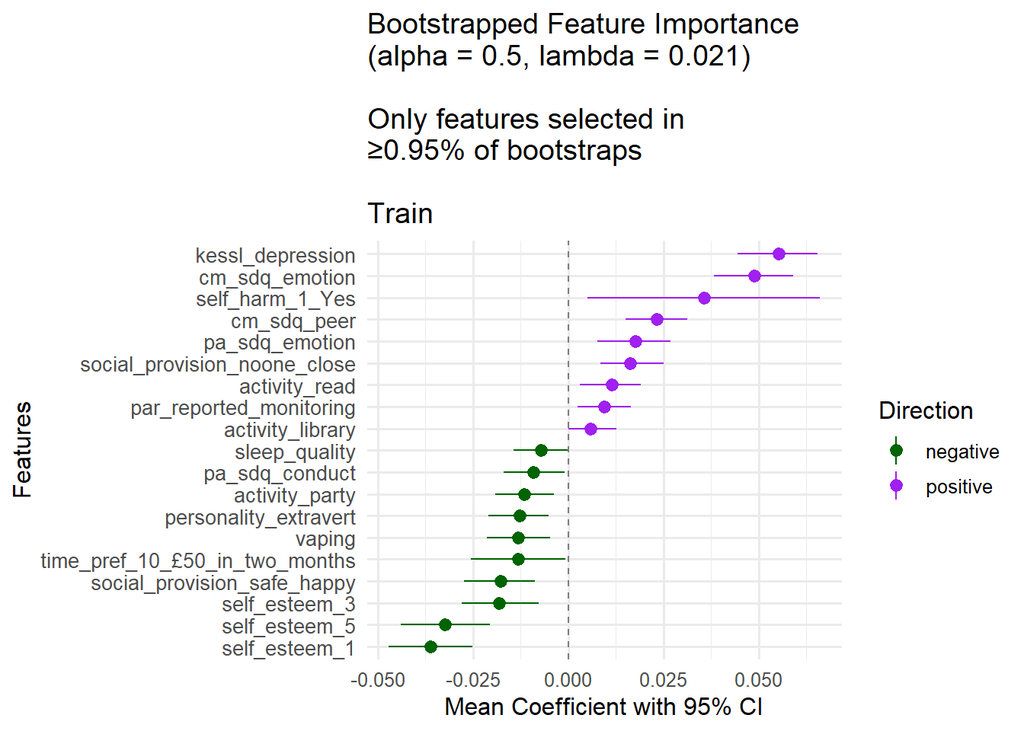

```r
# Print plots
print(results_highSMA_gmm3probC3$train$plot)
```

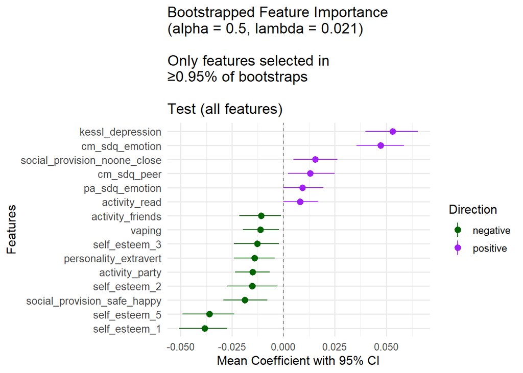

```r
print(results_highSMA_gmm3probC3$test_all$plot)
```

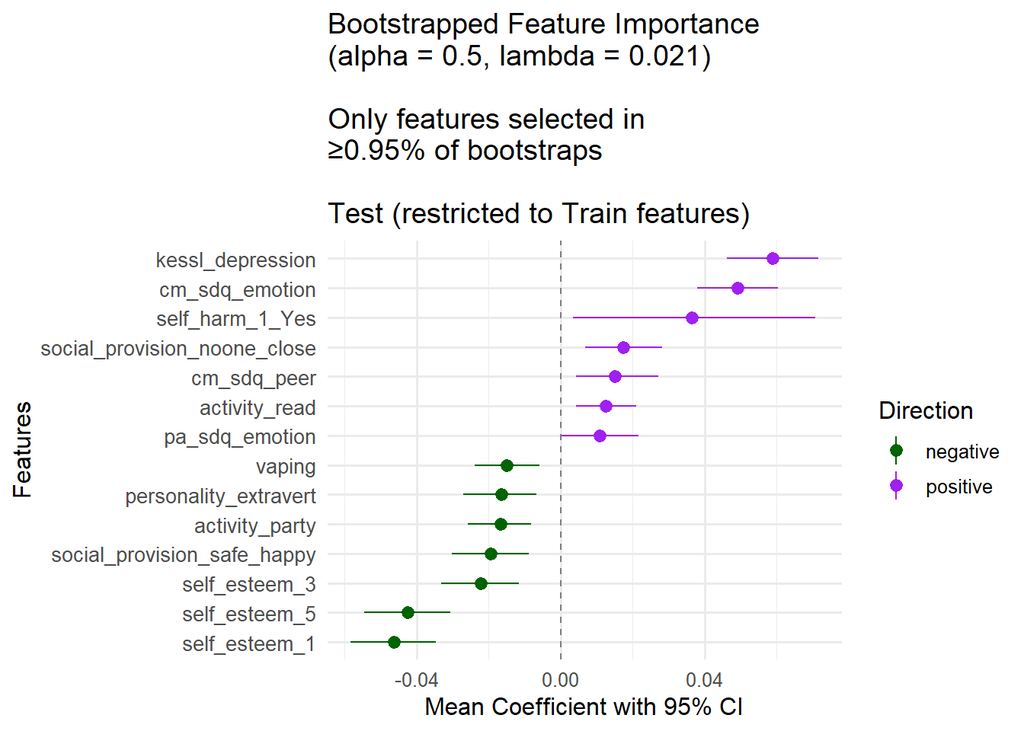

```r
print(results_highSMA_gmm3probC3$test_restricted$plot)
```

```r
####### Make Figure 3 top row

Fig03a_plot <- results_highSMA_gmm3probC1$test_restricted$plot +
    scale_x_discrete(
    labels = var_renames
  ) +
    scale_color_manual(
    values = c("positive" = highSMA_cluster_colours[["1"]], "negative" = highSMA_cluster_colours[["1"]])
  ) +
  labs(
    title = ""
  )
Fig03b_plot <- results_highSMA_gmm3probC2$test_restricted$plot +
    scale_x_discrete(
    labels = var_renames
  ) +
    scale_color_manual(
    values = c("positive" = highSMA_cluster_colours[["2"]], "negative" = highSMA_cluster_colours[["2"]])
  ) +
  labs(
    title = ""
  )
Fig03c_plot <- results_highSMA_gmm3probC3$test_restricted$plot +
    scale_x_discrete(
    labels = var_renames
  ) +
    scale_color_manual(
    values = c("positive" = highSMA_cluster_colours[["3"]], "negative" = highSMA_cluster_colours[["3"]])
  ) +
  labs(
    title = ""
  )
ggsave("figures/Fig03a.pdf", plot = Fig03a_plot, bg = "white", width = 7, height = 4.5, units = "in")
ggsave("figures/Fig03b.pdf", plot = Fig03b_plot, bg = "white", width = 7, height = 4.5, units = "in")
ggsave("figures/Fig03c.pdf", plot = Fig03c_plot, bg = "white", width = 7, height = 4.5, units = "in")
```

As a sensitivity analysis to see if the features are simply predicting SMA severity within the high SMA group rather than cluster membership, we see what happens within the SMA group if we just predict SMA answer (i.e., either Strongly agree or Agree). We find no predictors indicating the cluster differences are not just explained by SMA severity.

```r
dat_highSMA_SMA_ytrain <- dat_imputed_SMA_train %>%
    filter(sma == "Agree" | sma == "Strongly agree") %>%
    pull(sma) %>%
    factor(levels = sma_levels, ordered = TRUE) %>%
    as.numeric()

dat_highSMA_SMA_ytest <- dat_imputed_SMA_test %>%
    filter(sma == "Agree" | sma == "Strongly agree") %>%
    pull(sma) %>%
    factor(levels = sma_levels, ordered = TRUE) %>%
    as.numeric()


## run on training dataset to select optimal lambda value and get selected predictors

fit_highSMA_SMA <- cv.glmnet(
  as.matrix(dat_highSMA_xtrain), as.matrix(dat_highSMA_SMA_ytrain),
  type.measure = "mse",
  alpha        = 0.5,
  family       = "gaussian"
)

results_highSMA_SMA <- bootstrap_feature_importance_wrapper(
  dat_highSMA_xtrain, dat_highSMA_SMA_ytrain,
  dat_highSMA_xtest, dat_highSMA_SMA_ytest,
  alpha_val   = 0.5,
  lambda      = fit_highSMA_SMA$lambda.1se,
  colours     = c("purple", "darkgreen"),
  family      = "gaussian"
)
```

```
## Bootstrap iteration: 1 / 1000
```

```
## Bootstrap iteration: 100 / 1000
```

```
## Bootstrap iteration: 200 / 1000
```

```
## Bootstrap iteration: 300 / 1000
```

```
## Bootstrap iteration: 400 / 1000
```

```
## Bootstrap iteration: 500 / 1000
```

```
## Bootstrap iteration: 600 / 1000
```

```
## Bootstrap iteration: 700 / 1000
```

```
## Bootstrap iteration: 800 / 1000
```

```
## Bootstrap iteration: 900 / 1000
```

```
## Bootstrap iteration: 1000 / 1000
```

```
## Bootstrap iteration: 1 / 1000
```

```
## Bootstrap iteration: 100 / 1000
```

```
## Bootstrap iteration: 200 / 1000
```

```
## Bootstrap iteration: 300 / 1000
```

```
## Bootstrap iteration: 400 / 1000
```

```
## Bootstrap iteration: 500 / 1000
```

```
## Bootstrap iteration: 600 / 1000
```

```
## Bootstrap iteration: 700 / 1000
```

```
## Bootstrap iteration: 800 / 1000
```

```
## Bootstrap iteration: 900 / 1000
```

```
## Bootstrap iteration: 1000 / 1000
```

```
## No predictor variables from training survived into the restricted test set. Returning only Train and Test (all features).
```

```r
# Access tables
results_highSMA_SMA$train$summary
```

```
## # A tibble: 0 × 6
## # ℹ 6 variables: feature <chr>, mean <dbl>, lower <dbl>, upper <dbl>,
## #   prop_nonzero <dbl>, direction <lgl>
```

```r
results_highSMA_SMA$test_all$summary
```

```
## # A tibble: 0 × 6
## # ℹ 6 variables: feature <chr>, mean <dbl>, lower <dbl>, upper <dbl>,
## #   prop_nonzero <dbl>, direction <lgl>
```

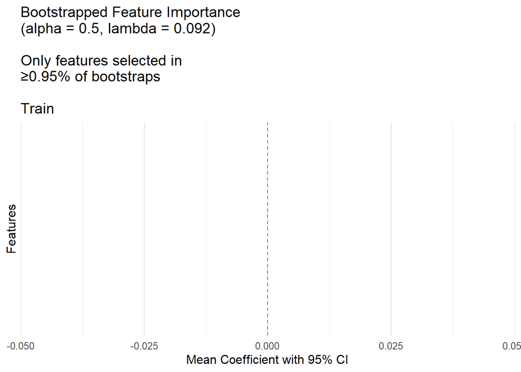

```r
# Print plots
print(results_highSMA_SMA$train$plot)
```

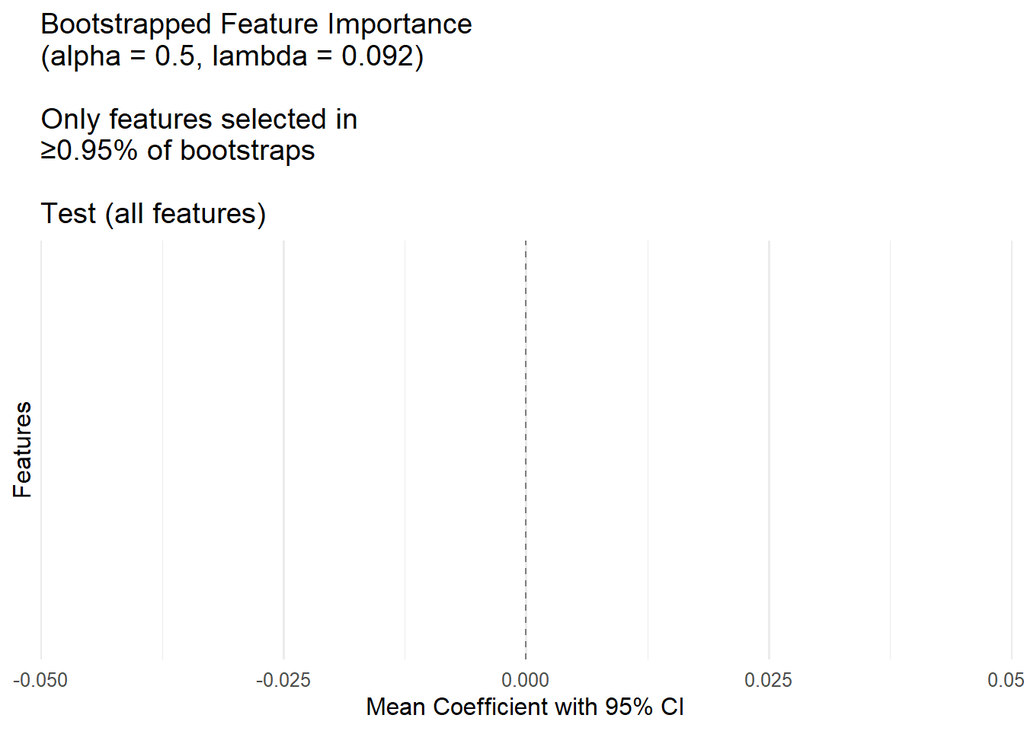

```r
print(results_highSMA_SMA$test_all$plot)
```

2. Next, we use regression to predict membership of each cluster compared to those NOT in the SMA group:

```r
### ========================
### gmm3 - Cluster 1
### ========================
dat_gmm3_C1_xtrain <- dat_imputed_all_train_clust %>%
  filter(gmm3_cluster == 1 | gmm3_cluster == 0) %>%
  select(-gmm3_cluster)
dat_gmm3_C1_ytrain <- dat_imputed_all_train_clust %>%
  filter(gmm3_cluster == 1 | gmm3_cluster == 0) %>%
  pull(gmm3_cluster)

dat_gmm3_C1_xtest <- dat_imputed_all_test_clust %>%
  filter(gmm3_cluster == 1 | gmm3_cluster == 0) %>%
  select(-gmm3_cluster)
dat_gmm3_C1_ytest <- dat_imputed_all_test_clust %>%
  filter(gmm3_cluster == 1 | gmm3_cluster == 0) %>%
  pull(gmm3_cluster)

fit_gmm3_C1 <- cv.glmnet(as.matrix(dat_gmm3_C1_xtrain),
                         as.matrix(dat_gmm3_C1_ytrain),
                         type.measure="mse",
                         alpha=0.5,
                         family="binomial")

results_highSMA_gmm3_C1 <- bootstrap_feature_importance_wrapper(
  dat_gmm3_C1_xtrain, dat_gmm3_C1_ytrain,
  dat_gmm3_C1_xtest, dat_gmm3_C1_ytest,
  alpha_val=0.5, lambda_val=fit_gmm3_C1$lambda.1se,
  n_bootstrap=1000, colours=c("purple","darkgreen"),
  family="binomial"
)
```

```
## Bootstrap iteration: 1 / 1000
```

```
## Bootstrap iteration: 100 / 1000
```

```
## Bootstrap iteration: 200 / 1000
```

```
## Bootstrap iteration: 300 / 1000
```

```
## Bootstrap iteration: 400 / 1000
```

```
## Bootstrap iteration: 500 / 1000
```

```
## Bootstrap iteration: 600 / 1000
```

```
## Bootstrap iteration: 700 / 1000
```

```
## Bootstrap iteration: 800 / 1000
```

```
## Bootstrap iteration: 900 / 1000
```

```
## Bootstrap iteration: 1000 / 1000
```

```
## Bootstrap iteration: 1 / 1000
```

```
## Bootstrap iteration: 100 / 1000
```

```
## Bootstrap iteration: 200 / 1000
```

```
## Bootstrap iteration: 300 / 1000
```

```
## Bootstrap iteration: 400 / 1000
```

```
## Bootstrap iteration: 500 / 1000
```

```
## Bootstrap iteration: 600 / 1000
```

```
## Bootstrap iteration: 700 / 1000
```

```
## Bootstrap iteration: 800 / 1000
```

```
## Bootstrap iteration: 900 / 1000
```

```
## Bootstrap iteration: 1000 / 1000
```

```
## Bootstrap iteration: 1 / 1000
```

```
## Bootstrap iteration: 100 / 1000
```

```
## Bootstrap iteration: 200 / 1000
```

```
## Bootstrap iteration: 300 / 1000
```

```
## Bootstrap iteration: 400 / 1000
```

```
## Bootstrap iteration: 500 / 1000
```

```
## Bootstrap iteration: 600 / 1000
```

```
## Bootstrap iteration: 700 / 1000
```

```
## Bootstrap iteration: 800 / 1000
```

```
## Bootstrap iteration: 900 / 1000
```

```
## Bootstrap iteration: 1000 / 1000
```

```r
# Access tables
results_highSMA_gmm3_C1$train$summary
```

```
## # A tibble: 15 × 6
##    feature                          mean    lower   upper prop_nonzero direction
##    <chr>                           <dbl>    <dbl>   <dbl>        <dbl> <chr>
##  1 activity_friends               0.0730  0        0.150         0.97  positive
##  2 activity_party                 0.135   4.20e-2  0.219         0.998 positive
##  3 activity_read                 -0.156  -2.32e-1 -0.0789        1     negative
##  4 doing_with_time_SCHOOL_AND_W…  0.216   7.18e-2  0.358         0.997 positive
##  5 pa_sdq_peer                   -0.0779 -1.60e-1  0             0.97  negative
##  6 personality_agreeable          0.0692  0        0.147         0.952 positive
##  7 personality_extravert          0.187   1.09e-1  0.270         1     positive
##  8 personality_neurot             0.125   3.92e-2  0.208         0.995 positive
##  9 self_control                  -0.216  -2.93e-1 -0.140         1     negative
## 10 self_esteem_4                  0.0862  0        0.172         0.965 positive
## 11 self_harm_1_Yes               -0.310  -6.00e-1 -0.0209        0.984 negative
## 12 social_provision_safe_happy    0.156   7.34e-2  0.237         1     positive
## 13 television_hrs                 0.0698  5.93e-4  0.135         0.977 positive
## 14 victimisation_gossip_Yes       0.247   8.64e-2  0.406         0.999 positive
## 15 victimisation_sexapproach_Yes  0.198   0        0.414         0.958 positive
```

```r
results_highSMA_gmm3_C1$test_all$summary
```

```
## # A tibble: 13 × 6
##    feature                        mean     lower    upper prop_nonzero direction
##    <chr>                         <dbl>     <dbl>    <dbl>        <dbl> <chr>
##  1 activity_gig                 0.129   0.0367    0.228          0.995 positive
##  2 activity_party               0.100   0         0.202          0.969 positive
##  3 activity_read               -0.114  -0.210    -0.0203         0.991 negative
##  4 cm_sdq_peer                 -0.0997 -0.204     0              0.962 negative
##  5 gaming_hrs                  -0.0917 -0.185    -0.00151        0.977 negative
##  6 personality_extravert        0.219   0.121     0.312          1     positive
##  7 personality_neurot           0.102   0.000291  0.197          0.976 positive
##  8 self_control                -0.238  -0.331    -0.142          1     negative
##  9 self_esteem_4                0.129   0.0134    0.235          0.983 positive
## 10 social_provision_safe_happy  0.115   0.0154    0.223          0.99  positive
## 11 television_hrs               0.120   0.0355    0.208          0.996 positive
## 12 victimisation_gossip_Yes     0.210   0.00983   0.420          0.979 positive
## 13 victimisation_harass_Yes     0.260   0         0.498          0.974 positive
```

```r
results_highSMA_gmm3_C1$test_restricted$summary
```

```
## # A tibble: 12 × 6
##    feature                          mean   lower    upper prop_nonzero direction
##    <chr>                           <dbl>   <dbl>    <dbl>        <dbl> <chr>
##  1 activity_party                 0.140   0.0456  0.233          0.998 positive
##  2 activity_read                 -0.0946 -0.187  -0.00411        0.984 negative
##  3 doing_with_time_SCHOOL_AND_W…  0.174   0       0.352          0.971 positive
##  4 pa_sdq_peer                   -0.102  -0.197  -0.0117         0.99  negative
##  5 personality_agreeable          0.102   0.0134  0.189          0.988 positive
##  6 personality_extravert          0.280   0.190   0.370          1     positive
##  7 personality_neurot             0.108   0.0136  0.200          0.987 positive
##  8 self_control                  -0.212  -0.300  -0.119          1     negative
##  9 self_esteem_4                  0.193   0.100   0.288          1     positive
## 10 social_provision_safe_happy    0.164   0.0674  0.266          1     positive
## 11 television_hrs                 0.0945  0.0146  0.179          0.991 positive
## 12 victimisation_gossip_Yes       0.191   0.0111  0.367          0.984 positive
```

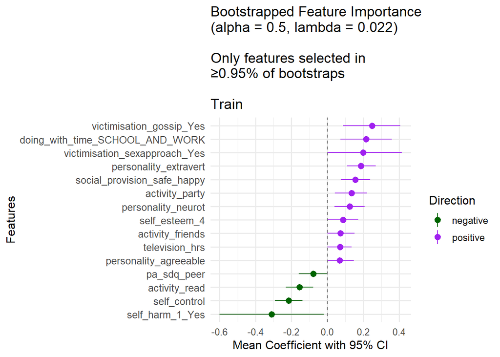

```r
# Print plots
print(results_highSMA_gmm3_C1$train$plot)
```

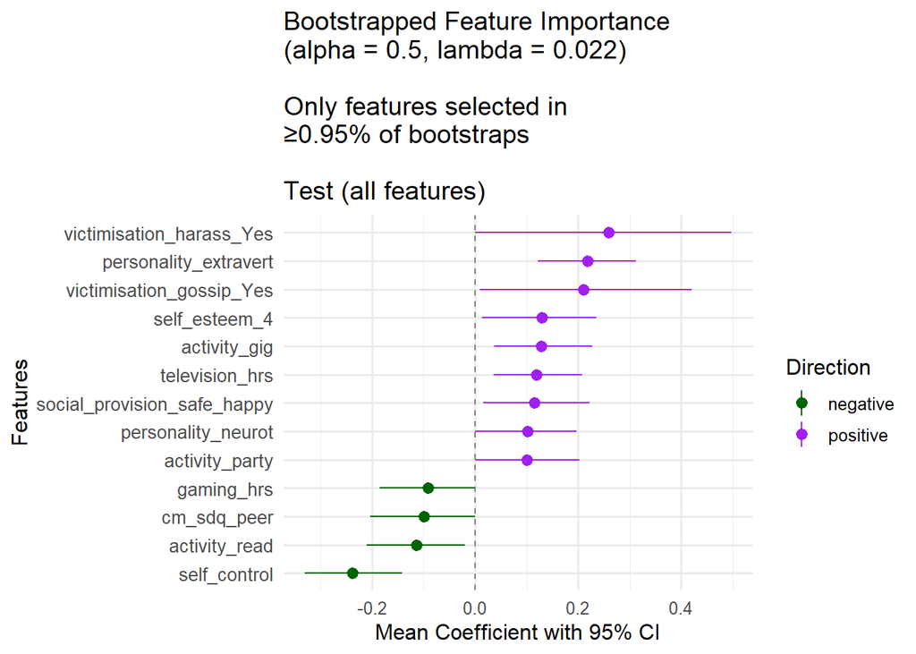

```r
print(results_highSMA_gmm3_C1$test_all$plot)
```

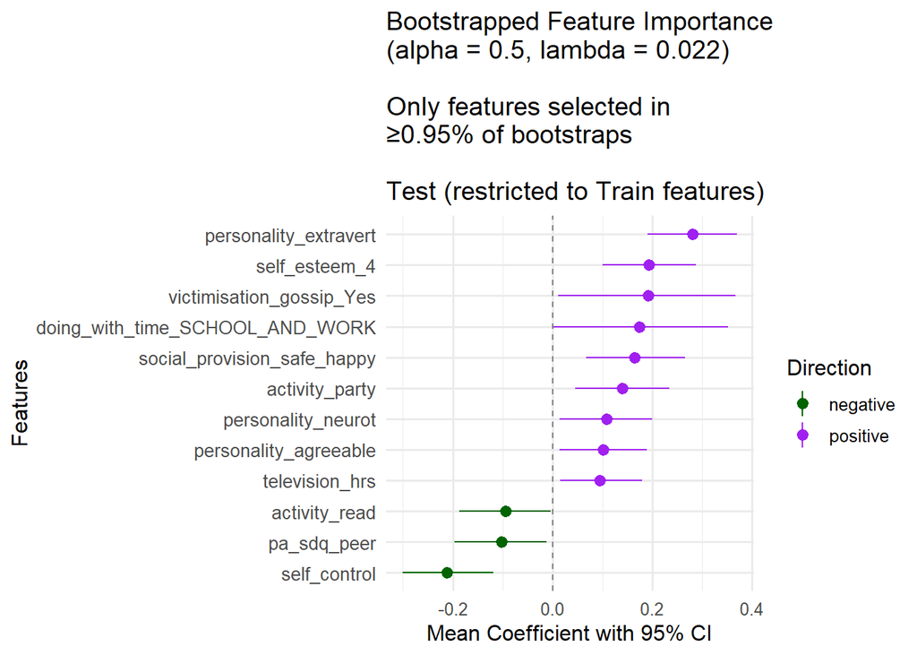

```r
print(results_highSMA_gmm3_C1$test_restricted$plot)
```

```r
### ========================
### gmm3 - Cluster 2
### ========================
dat_gmm3_C2_xtrain <- dat_imputed_all_train_clust %>%
  filter(gmm3_cluster == 2 | gmm3_cluster == 0) %>%
  select(-gmm3_cluster)
dat_gmm3_C2_ytrain <- dat_imputed_all_train_clust %>%
  filter(gmm3_cluster == 2 | gmm3_cluster == 0) %>%
  pull(gmm3_cluster)

dat_gmm3_C2_xtest <- dat_imputed_all_test_clust %>%
  filter(gmm3_cluster == 2 | gmm3_cluster == 0) %>%
  select(-gmm3_cluster)
dat_gmm3_C2_ytest <- dat_imputed_all_test_clust %>%
  filter(gmm3_cluster == 2 | gmm3_cluster == 0) %>%
  pull(gmm3_cluster)

fit_gmm3_C2 <- cv.glmnet(as.matrix(dat_gmm3_C2_xtrain), as.matrix(dat_gmm3_C2_ytrain),
                         type.measure="mse", alpha=0.5, family="binomial")

results_highSMA_gmm3_C2 <- bootstrap_feature_importance_wrapper(
  dat_gmm3_C2_xtrain, dat_gmm3_C2_ytrain,
  dat_gmm3_C2_xtest, dat_gmm3_C2_ytest,
  alpha_val=0.5, lambda_val=fit_gmm3_C2$lambda.1se,
  n_bootstrap=1000, colours=c("purple","darkgreen"),
  family="binomial"
)
```

```
## Bootstrap iteration: 1 / 1000
```

```
## Bootstrap iteration: 100 / 1000
```

```
## Bootstrap iteration: 200 / 1000
```

```
## Bootstrap iteration: 300 / 1000
```

```
## Bootstrap iteration: 400 / 1000
```

```
## Bootstrap iteration: 500 / 1000
```

```
## Bootstrap iteration: 600 / 1000
```

```
## Bootstrap iteration: 700 / 1000
```

```
## Bootstrap iteration: 800 / 1000
```

```
## Bootstrap iteration: 900 / 1000
```

```
## Bootstrap iteration: 1000 / 1000
```

```
## Bootstrap iteration: 1 / 1000
```

```
## Bootstrap iteration: 100 / 1000
```

```
## Bootstrap iteration: 200 / 1000
```

```
## Bootstrap iteration: 300 / 1000
```

```
## Bootstrap iteration: 400 / 1000
```

```
## Bootstrap iteration: 500 / 1000
```

```
## Bootstrap iteration: 600 / 1000
```

```
## Bootstrap iteration: 700 / 1000
```

```
## Bootstrap iteration: 800 / 1000
```

```
## Bootstrap iteration: 900 / 1000
```

```
## Bootstrap iteration: 1000 / 1000
## Bootstrap iteration: 1 / 1000
```

```
## Bootstrap iteration: 100 / 1000
```

```
## Bootstrap iteration: 200 / 1000
```

```
## Bootstrap iteration: 300 / 1000
```

```
## Bootstrap iteration: 400 / 1000
```

```
## Bootstrap iteration: 500 / 1000
```

```
## Bootstrap iteration: 600 / 1000
```

```
## Bootstrap iteration: 700 / 1000
```

```
## Bootstrap iteration: 800 / 1000
```

```
## Bootstrap iteration: 900 / 1000
```

```
## Bootstrap iteration: 1000 / 1000
```

```r
# Access tables
results_highSMA_gmm3_C2$train$summary
```

```
## # A tibble: 15 × 6
##    feature                       mean   lower     upper prop_nonzero direction
##    <chr>                        <dbl>   <dbl>     <dbl>        <dbl> <chr>
##  1 activity_museum           -0.117   -0.386  -0.0835          0.996 negative
##  2 activity_party             0.206    0.143   0.445           0.997 positive
##  3 activity_read             -0.158   -0.373  -0.0786          0.997 negative
##  4 activity_volunteering      0.0828  -0.272   0               0.958 positive
##  5 cm_sdq_conduct             0.254    0.198   0.471           0.997 positive
##  6 cm_sdq_hyper              -0.0250   0.0658  0.364           0.995 negative
##  7 pa_sdq_conduct             0.0682   0       0.270           0.967 positive
##  8 pa_sdq_hyper               0.181    0.156   0.424           0.997 positive
##  9 pa_sdq_prosoc             -0.159   -0.391  -0.107           0.997 negative
## 10 par_reported_monitoring   -0.0294  -0.250   0               0.961 negative
## 11 personality_conscientious -0.0672  -0.440  -0.125           0.997 negative
## 12 personality_extravert      0.184    0       0.286           0.972 positive
## 13 self_control               0.00155 -0.310  -0.000741        0.977 positive
## 14 television_hrs             0.128    0.0616  0.346           0.997 positive
## 15 vaping                     0.294    0.227   0.460           0.997 positive
```

```r
results_highSMA_gmm3_C2$test_all$summary
```

```
## # A tibble: 0 × 6
## # ℹ 6 variables: feature <chr>, mean <dbl>, lower <dbl>, upper <dbl>,
## #   prop_nonzero <dbl>, direction <lgl>
```

```r
results_highSMA_gmm3_C2$test_restricted$summary
```

```
## # A tibble: 11 × 6
##    feature                     mean   lower    upper prop_nonzero direction
##    <chr>                      <dbl>   <dbl>    <dbl>        <dbl> <chr>
##  1 activity_museum           -0.313 -0.498  -0.115          0.998 negative
##  2 activity_party             0.342  0.161   0.525          1     positive
##  3 activity_read             -0.348 -0.523  -0.163          1     negative
##  4 activity_volunteering     -0.178 -0.367   0              0.968 negative
##  5 cm_sdq_conduct             0.408  0.250   0.571          1     positive
##  6 pa_sdq_conduct             0.343  0.195   0.506          1     positive
##  7 pa_sdq_prosoc             -0.239 -0.412  -0.0764         1     negative
##  8 par_reported_monitoring   -0.193 -0.351  -0.0255         0.989 negative
##  9 personality_conscientious -0.383 -0.569  -0.191          1     negative
## 10 self_control              -0.184 -0.361  -0.00619        0.979 negative
## 11 vaping                     0.172  0.0125  0.307          0.98  positive
```

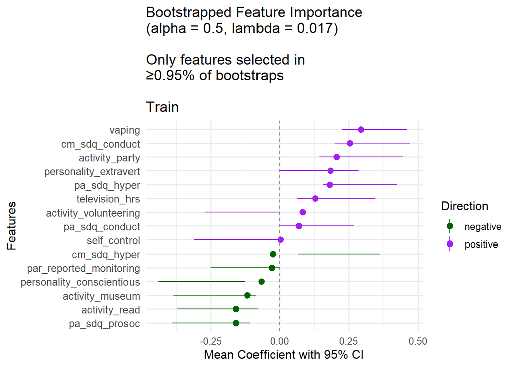

```r
# Print plots
print(results_highSMA_gmm3_C2$train$plot)
```

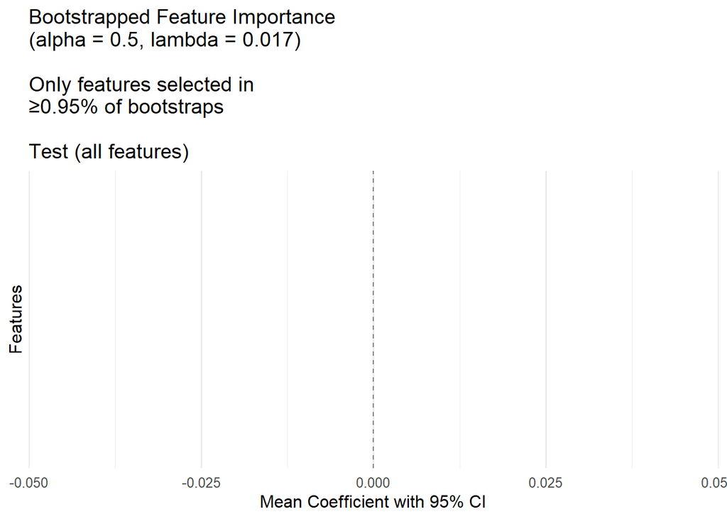

```r
print(results_highSMA_gmm3_C2$test_all$plot)
```

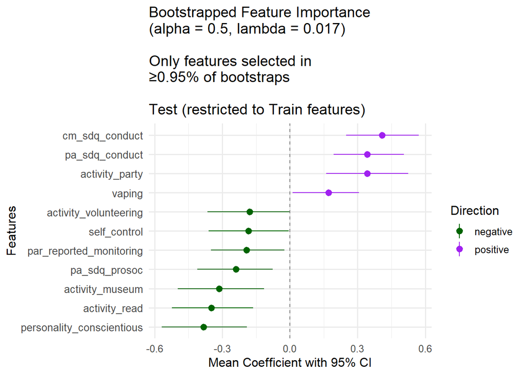

```r
print(results_highSMA_gmm3_C2$test_restricted$plot)
```

```r
### ========================
### gmm3 - Cluster 3
### ========================
dat_gmm3_C3_xtrain <- dat_imputed_all_train_clust %>%
  filter(gmm3_cluster == 3 | gmm3_cluster == 0) %>%
  select(-gmm3_cluster)
dat_gmm3_C3_ytrain <- dat_imputed_all_train_clust %>%
  filter(gmm3_cluster == 3 | gmm3_cluster == 0) %>%
  pull(gmm3_cluster)

dat_gmm3_C3_xtest <- dat_imputed_all_test_clust %>%
  filter(gmm3_cluster == 3 | gmm3_cluster == 0) %>%
  select(-gmm3_cluster)
dat_gmm3_C3_ytest <- dat_imputed_all_test_clust %>%
  filter(gmm3_cluster == 3 | gmm3_cluster == 0) %>%
  pull(gmm3_cluster)

fit_gmm3_C3 <- cv.glmnet(as.matrix(dat_gmm3_C3_xtrain), as.matrix(dat_gmm3_C3_ytrain),
                         type.measure="mse", alpha=0.5, family="binomial")

results_highSMA_gmm3_C3 <- bootstrap_feature_importance_wrapper(
  dat_gmm3_C3_xtrain, dat_gmm3_C3_ytrain,
  dat_gmm3_C3_xtest, dat_gmm3_C3_ytest,
  alpha_val=0.5, lambda_val=fit_gmm3_C3$lambda.1se,
  n_bootstrap=1000, colours=c("purple","darkgreen"),
  family="binomial"
)
```

```
## Bootstrap iteration: 1 / 1000
```

```
## Bootstrap iteration: 100 / 1000
```

```
## Bootstrap iteration: 200 / 1000
```

```
## Bootstrap iteration: 300 / 1000
```

```
## Bootstrap iteration: 400 / 1000
```

```
## Bootstrap iteration: 500 / 1000
```

```
## Bootstrap iteration: 600 / 1000
```

```
## Bootstrap iteration: 700 / 1000
```

```
## Bootstrap iteration: 800 / 1000
```

```
## Bootstrap iteration: 900 / 1000
```

```
## Bootstrap iteration: 1000 / 1000
```

```
## Bootstrap iteration: 1 / 1000
```

```
## Bootstrap iteration: 100 / 1000
```

```
## Bootstrap iteration: 200 / 1000
```

```
## Bootstrap iteration: 300 / 1000
```

```
## Bootstrap iteration: 400 / 1000
```

```
## Bootstrap iteration: 500 / 1000
```

```
## Bootstrap iteration: 600 / 1000
```

```
## Bootstrap iteration: 700 / 1000
```

```
## Bootstrap iteration: 800 / 1000
```

```
## Bootstrap iteration: 900 / 1000
```

```
## Bootstrap iteration: 1000 / 1000
```

```
## Bootstrap iteration: 1 / 1000
```

```
## Bootstrap iteration: 100 / 1000
```

```
## Bootstrap iteration: 200 / 1000
```

```
## Bootstrap iteration: 300 / 1000
```

```
## Bootstrap iteration: 400 / 1000
```

```
## Bootstrap iteration: 500 / 1000
```

```
## Bootstrap iteration: 600 / 1000
```

```
## Bootstrap iteration: 700 / 1000
```

```
## Bootstrap iteration: 800 / 1000
```

```
## Bootstrap iteration: 900 / 1000
```

```
## Bootstrap iteration: 1000 / 1000
```

```r
results_highSMA_gmm3_C3$train$summary
```

```
## # A tibble: 5 × 6
##   feature               mean   lower   upper prop_nonzero direction
##   <chr>                <dbl>   <dbl>   <dbl>        <dbl> <chr>
## 1 cm_sdq_emotion      0.366   0.277   0.445         1     positive
## 2 kessl_depression    0.313   0.230   0.400         1     positive
## 3 personality_neurot  0.164   0.0875  0.246         0.999 positive
## 4 self_esteem_5      -0.163  -0.245  -0.0783        1     negative
## 5 warwick_wellbeing  -0.0723 -0.156   0             0.965 negative
```

```r
results_highSMA_gmm3_C3$test_all$summary
```

```
## # A tibble: 7 × 6
##   feature                         mean  lower  upper prop_nonzero direction
##   <chr>                          <dbl>  <dbl>  <dbl>        <dbl> <chr>
## 1 cm_sdq_emotion                0.271   0.177  0.368        1     positive
## 2 kessl_depression              0.252   0.143  0.362        1     positive
## 3 personality_neurot            0.0848  0      0.179        0.971 positive
## 4 self_esteem_1                -0.212  -0.311 -0.118        1     negative
## 5 self_esteem_3                -0.0930 -0.196  0            0.954 negative
## 6 self_esteem_5                -0.206  -0.312 -0.104        1     negative
## 7 social_provision_noone_close  0.106   0      0.194        0.973 positive
```

```r
results_highSMA_gmm3_C3$test_restricted$summary
```

```
## # A tibble: 5 × 6
##   feature               mean    lower  upper prop_nonzero direction
##   <chr>                <dbl>    <dbl>  <dbl>        <dbl> <chr>
## 1 cm_sdq_emotion      0.317   0.222    0.414        1     positive
## 2 kessl_depression    0.324   0.212    0.429        1     positive
## 3 personality_neurot  0.0930  0.00346  0.188        0.978 positive
## 4 self_esteem_5      -0.382  -0.494   -0.268        1     negative
## 5 warwick_wellbeing  -0.107  -0.207    0            0.971 negative
```